# Curso avanzado de programación AWK y Bash para bioinformática y biocómputo en sistemas GNU/Linux

Pablo Vinuesa, Centro de Ciencias Genómicas - UNAM; https://www.ccg.unam.mx/~vinuesa/ | @pvinmex: https://twitter.com/pvinmex

Versión: Mon Sep 26 22:11:44 2022

# 1 Presentación

Este tutorial es desarrollado por [Pablo Vinuesa, CCG-UNAM](http://www.ccg.unan.mx/~vinuesa/) ([twitter: @pvinmex](https://twitter.com/pvinmex)) a partir de material previo, presentado en diversos cursos y talleres, como [Taller 3 - Análisis comparativo de genomas microbianos: Pangenómica y filoinformática](http://congresos.nnb.unam.mx/TIB2019/t3-analisis-comparativo-de-genomas-microbianos-pangenomica-y-filoinformatica/) de los [Talleres Internacionales de Bioinformática - TIB2019](http://congresos.nnb.unam.mx/TIB2019), celebrados en el [Centro de Ciencias Genómicas](http://www.ccg.unam.mx) de la [Universidad Nacional Autónoma de México](http://www.ccg.unam.mx), del 29 de julio al 2 de agosto de 2019.

Las versión actual (v.2022-09-26) contiene extensiones significativas con respecto a cursos anteriores, así como adaptaciones para el [Taller de Ciencias Genómicas: de Moléculas a Ecosistemas](http://www.ccg.unam.mx/noticias/academicas/taller-de-ciencias-genomicas-de-moleculas-a-ecosistemas/), que impartimos investigadores del [CCG-UNAM](http://www.ccg.unam.mx) para alumn@s de la [Facultad de Ciencias - UNAM](http://www.fciencias.unam.mx/), así como para el curso de introducción a Linux que imparto en la [Licenciatura en Ciencias Genómicas - LCG de la UNAM](https://www.lcg.unam.mx/).

Si éste es tu primer contacto con Linux, te recomiendo que leas primero esta [presentación sobre introducción al biocómputo en sistemas Linux - PDF](https://github.com/vinuesa/intro2linux/blob/master/docs/intro_biocomputo_Linux.pdf).

## 1.1 Objetivos

Este documento sirve tanto como un **tutorial completo de iniciación a la programación en $AWK$ y $Bash$ para bioinformática** para los que no han tenido contacto previo con un sistema UNIX o GNU/Linux, como una **referencia para usuarios avanzados**.

Como muestra el [índice](https://vinuesa.github.io/intro2linux/index.html), el tutorial avanza desde los aspectos más elementales de conexión a un servidor, navegación del sistema, propiedades de archivos y tuberías de filtrado de texto, a programación avanzada en **AWK** y **BASH**. Contiene muchísimos ejemplos prácticos, desde programas simples pero siempre útiles para ejecutar en la consola de comandos (*1liners*), a *scripts* avanzados, aptos para el trabajo de investigación en el área como [**fasta_toolkit.awk**](https://vinuesa.github.io/intro2linux/index.html#fasta_toolkit.awk-un-script-multifuncional-para-mainpular-archivo-fasta-que-hace-uso-de-getopt), **extract_CDSs_from_GenBank.awk** y [**run_phylip.sh**](https://vinuesa.github.io/intro2linux/index.html#el-script-run_phylip.sh). Éstos hacen uso de funciones, banderas, estructuras de control de flujo, estructuras de datos complejas, menús de usuario, y muchos otros atributos propios de programas profesionales. Estos ejemplos te servirán para aprender a programar herramientas bioinformáticas robustas y modulares, siguiendo mejores prácticas. El tutorial te enseña el uso práctico de todos los elementos sintácticos implementados en dichos *scripts*, los cuales puedes descargar del [repositorio GitHub de este curso](https://github.com/vinuesa/intro2linux). Estos programas se describen en detalle en este documento.

## 1.2 Licencia y términos de uso

Este material didáctico lo distribuyo públicamente a través de este [repositorio GitHub intro2linux](https://github.com/vinuesa/intro2linux) bajo la [**Licencia No Comercial Creative Commons 4.0**](https://creativecommons.org/licenses/by-nc/4.0/)

This work is licensed under a [Creative Commons Attribution-NonCommercial 4.0](http://creativecommons.org/licenses/by-nc/4.0/)

El código se distribuye bajo la licencia [GNU General Public License v3](https://www.gnu.org/licenses/gpl-3.0.html)

## 1.3 ¿Cómo correr los ejemplos de este manual?

Idealmente debes tener acceso local o remoto a una máquina UNIX o GNU/Linux. Si tienes una máquina Windows, otra opción es instalar [mobaXterm home edition](https://mobaxterm.mobatek.net/download-home-edition.html), como se explica en el esta [sección README del repositorio](https://github.com/vinuesa/intro2linux#instalaci%C3%B3n-de-mobaxterm-en-m%C3%A1quinas-windows-para-poder-establecer-sesiones-ssh-a-un-servidor)

## 1.4 ¿Cómo obtener la última versión de este documento?

Tienes básicamente 2 opciones:

1. clonar el [repositorio intro2linux](https://github.com/vinuesa/intro2linux) y correr con frecuencia el comando

   ```
   git
   pull
   ```

   , como se explica en el [REAEME del repositorio](https://github.com/vinuesa/intro2linux)
2. navegar y/o descargar directamente el [archivo html del manual](https://vinuesa.github.io/intro2linux/index.html)

La primera es la más conveniente, ya que no sólo descargas el [archivo html del curso](https://vinuesa.github.io/intro2linux/index.html), sino todos los *scripts* y datos asociados para que puedas seguir cada ejemplo.

# 2 El Proyecto de Software Libre GNU

Bienvenid@s al mundo de cómputo y software libre del [proyecto GNU](https://www.gnu.org/). Antes de empezar este tutorial, sugiero que te informes sobre lo que es el proyecto [GNU](https://www.gnu.org/), iniciado por [Richard Stallman (*rms*)](https://en.wikipedia.org/wiki/Richard_Stallman) en 1983 y desarrollado por una enorme comunidad de programadores, y su relación con Linux, para formar el sistema de cómputo libre [GNU/Linux](https://www.gnu.org/gnu/linux-and-gnu.html).

Así lo explica *rms* en su artículo [Linux y el sistema GNU](https://www.gnu.org/gnu/linux-and-gnu.es.html), del que cito los primeros dos párrafos abajo:

*Muchos usuarios de ordenadores ejecutan a diario, sin saberlo, una versión modificada del sistema GNU. Debido a un peculiar giro de los acontecimientos, a la versión de GNU ampliamente utilizada hoy en día se la llama a menudo «Linux», y muchos de quienes la usan no se dan cuenta de que básicamente se trata del sistema GNU, desarrollado por el proyecto GNU.*

Efectivamente existe un Linux, y estas personas lo usan, pero constituye solo una parte del sistema que utilizan. **Linux es el núcleo**: el programa del sistema que se encarga de asignar los recursos de la máquina a los demás programas que el usuario ejecuta. El núcleo es una parte esencial de un sistema operativo, pero inútil por sí mismo, sólo puede funcionar en el marco de un sistema operativo completo. **Linux se utiliza normalmente en combinación con el sistema operativo GNU: el sistema completo es básicamente GNU al que se le ha añadido Linux**, es decir, **GNU/Linux**. Todas las distribuciones denominadas «Linux» son en realidad distribuciones GNU/Linux.

– Richard M. Stallman

- [The GNU project](https://www.gnu.org/gnu/gnu-history.html)
- [Free Software Education](https://www.gnu.org/education/education.html)
- [Free Software - Richard Stallman](https://audio-video.gnu.org/video/rms-education-es-high-sub.en.ogv) <== no dejes de ver este video
- [GNU software](https://www.gnu.org/software/software.html)
- [la relación entre GNU y Linux](https://www.gnu.org/gnu/linux-and-gnu.html)

## 2.1 La controversia sobre el nombre: ¿GNU/Linux o sólo Linux?

Hay que aclarar que destacados miembros de la comunidad de desarrolladores de software libre esgrimen diversos argumentos por los que consideran que el sistema no se debe llamar [GNU/Linux](https://en.wikipedia.org/wiki/GNU/Linux_naming_controversy), favoreciendo el nombre de *Linux*.

Sirva de ejemplo uno de los comentario de [Linus Torvalds](https://es.wikipedia.org/wiki/Linus_Torvalds):

*Umm, this discussion has gone on quite long enough, thank you very much. It doesn’t really matter what people call Linux, as long as credit is given where credit is due (on both sides). Personally, I’ll very much continue to call it “Linux”, …*

The GNU people tried calling it GNU/Linux, and that’s ok. It’s certainly no worse a name than “Linux Pro” or “Red Hat Linux” or “Slackware Linux” …

Lignux is just a punny name—I think Linux/GNU or GNU/Linux is a bit more “professional” …

– Linus Torvalds

Es importante notar que muchas de las [distribuciones de Linux](https://es.wikipedia.org/wiki/Distribuci%C3%B3n_Linux), incluyendo [Ubuntu](https://ubuntu.com/), no siguen estrictamente el principio de software libre de GNU. Ubuntu, por ejemplo, incluye el repositorio $restricted$, que contiene paquetes soportados por los desarrolladores de Ubuntu debido a su importancia, pero que no está disponible bajo ningún tipo de licencia libre. Ejemplos notables son los controladores propietarios de algunas tarjetas gráficas, como los de ATI y NVIDIA. Ello ha permitido que Ubuntu sea una de las distribuciones de Linux con mayor compatibilidad de *hardware* y facilidad de instalación. Por ello recomiendo y uso esta *distro*.

## 2.2 Nota de agradecimiento y postura personal

En lo personal, soy pragmático y agnóstico en lo que respecta a la controversia. Estoy muy agradecido a toda la comunidad por haber desarrollado, integrado y puesto a nuestra disposición esta maravilla de entorno de cómputo libre: *kernel*, sistema operativo y software. Por ello gustosamente doy crédito al proyecto [GNU](https://www.gnu.org/) y al el núcleo o [*kernel*](https://es.wikipedia.org/wiki/N%C3%BAcleo_Linux), desarrollado originalmente por [Linus Torvalds](https://es.wikipedia.org/wiki/Linus_Torvalds) y conocido actualmente como [núcleo Linux](https://www.kernel.org/). Desde el año 2004 realizo todo mi trabajo en este entorno.

Como académico coincido plenamente con la visión de *rms* en que [los centros de educación pública deberían de usar el entorno GNU/Linux](https://audio-video.gnu.org/video/rms-education-es-high-sub.en.ogv), idealmente desde la secundaria. En diversos lugares, notablemente en India, este mensaje de *rms* ha calado hondo. El estado de Kerala fue pionero: [desde 2006 toda la educación pública de Kerala se hace en en el entorno GNU/Linux](https://web.archive.org/web/20061208075556/http://www.financialexpress.com/fe_full_story.php?content_id=138464), habiendo eliminado Windows y software privativo de las escuelas estatales. Otros estados como Karnataka, Gujarat, Assam, West Bengal siguieron rápidamente el ejemplo, incorporando [software libre y código fuente abierto - OSS´](https://www.gnu.org/home.es.html#mission-statement) como una clave de sus sistemas educativos. Es una tendencia respaldada actualmente por el gobierno Indio, como pueden leer aquí: [Adoption of Free and Open Source Software in India](https://www.ripublication.com/ijaer18/ijaerv13n16_44.pdf). El resultado es contundente - la India es actualmente una potencia mundial en cómputo y matemáticas.

Mi modesta pero activa manera de contribuir a la promoción del uso de [software libre y código fuente abierto](https://es.wikipedia.org/wiki/Software_libre_y_de_c%C3%B3digo_abierto) en México y Latinoamérica es [divulgando el uso del ambiente de cómputo GNU/Linux a alumnos universitarios mediante cursos en diversos países de habla hispana](https://www.ccg.unam.mx/~vinuesa/cursos.html), y promoviendo su implementación en la universidad, particularmente en la [LCG-UNAM](https://www.lcg.unam.mx/). Me referiré a este ambiente de cómputo con ambos nombres (GNU/Linux y Linux), para expresar mi neutralidad al respecto de la controversia arriba mencionada, aunque tiendo a preferir el uso de GNU/Linux para remarcar el crédito a todos los componentes de esta extraordinaria “simbiosis”.

## 2.3 GNU - Documentación y recursos

[figure not shown]

Todo software de calidad debe de estar bien documentado. Sin duda la [documentación del software GNU](https://www.gnu.org/manual/manual.html) es extraordinaria. No dejes de visitar al menos estos recursos:

- [GNU - awk manual](https://www.gnu.org/software/gawk/manual/gawk.html)
- [GNU - bash manual](https://www.gnu.org/software/bash/manual/bash.html)

### 2.3.1 Referencias adicionales

Una vez que domines los comandos básicos que se presentarán en este documento, recomiendo revisar tutoriales más detallados y completos como los siguientes:

- [The Linux Command Line - a complete introduction. William E. Shotts, Jr. No Starch Press](http://linuxcommand.org/lc3_learning_the_shell.php#contents)
- [Bash Reference Manual](https://tiswww.case.edu/php/chet/bash/bashref.html)
- [Advanced Bash Scripting Guide](http://tldp.org/LDP/abs/html/)
- [Bioinformatics Data Skills: Reproducible and Robust Research with Open Source Tools. Vince Buffalo. O’Reilly Media 2014](http://freecomputerbooks.com/Bioinformatics-Data-Skills.html)

# 3 Primer contacto con un sistema Linux - navegación del sistema

Si no has trabajado previamente con la consola de comandos, debes empezar en esta sección que te guiará paso a paso para aprender rápidamente los fundamentos del $Shell$.

## 3.1 Conexión a un servidor y exploración de sus características básicas

Estas prácticas están diseñadas para correr en un **servidor** remoto, pero puedes hacerlo también en una **sesión local**, es decir, en tu máquina. Sólo tienes que poner en un directorio los archivos con los que vamos a trabajar, los cuales puedes [descargar del directorio intro2linux/data del sitio GitHub](https://github.com/vinuesa/intro2linux/tree/master/docs/data).

### 3.1.1 **ssh** establecer sesion remota encriptada (segura) via ssh al servidor con número dado de IP

```
ssh -l $USER IP
```

- Nota: para poder desplegar el ambiente gráfico en el servidor remoto debemos hacer el *login* con:

```
ssh -X $USER@IP
```

Al establecer una sesión remota vía $ssh$, la inicias en tu $HOME$

### 3.1.2 **hostname** muestra el nombre del host (la máquina a la que estoy conectado) y la IP

```bash
hostname
hostname -i
```

```
## alisio
## 127.0.1.1
```

### 3.1.3 **uname** muestra información sobre el sistema y detalles del *kernel* o núcleo

```bash
uname
uname -a
```

```
## Linux
## Linux alisio 5.15.0-48-generic #54~20.04.1-Ubuntu SMP Thu Sep 1 16:17:26 UTC 2022 x86_64 x86_64 x86_64 GNU/Linux
```

### 3.1.4 **lsb_release** muestra información sobre la distribución instalada

```bash
lsb_release -a
```

```
## No LSB modules are available.
## Distributor ID:  Ubuntu
## Description: Ubuntu 20.04.5 LTS
## Release: 20.04
## Codename:    focal
```

### 3.1.5 **df** reporta el uso de disco del sistema

`df -h`

```
Filesystem            Size  Used Avail Use% Mounted on
/dev/mapper/VolGroup00-LogVol00
                       40G  2,6G   35G   7% /
tmpfs                 174G  3,1G  171G   2% /dev/shm
/dev/sda3             190M   90M   91M  50% /boot
/dev/mapper/VolGroup00-LogVol05
                     1012G  913G   49G  95% /home
/dev/mapper/VolGroup00-LogVol03
                       30G   23M   28G   1% /tmp
/dev/mapper/VolGroup00-LogVol02
                       59G   16G   41G  28% /usr
/dev/mapper/VolGroup00-LogVol04
                       79G  9,1G   66G  13% /var
/dev/mapper/VolGroup01-LogVol00
                      739G  518G  184G  74% /export/apps
/dev/mapper/VolGroup01-LogVol01
                       17T   16T  731G  96% /export/space1
buluc-cluster:/export/space2/users
                       17T   17T  461G  98% /export/space2/users
bonampak-cluster:/space29/data
                       12T   11T  938G  92% /export/space29/data
```

### 3.1.6 **free** reporta la memoria del sistema y *kernel*

`free -g # -g indica la memoria en gibibytes`

```
             total       used       free     shared    buffers     cached
Mem:           346        253         93          0          2        197
-/+ buffers/cache:         53        293
Swap:          351         16        335
```

### 3.1.7 **top** o **htop** muestran los procesos en ejecución y los recursos que consumen

`htop # sales con q o CTRL-c`

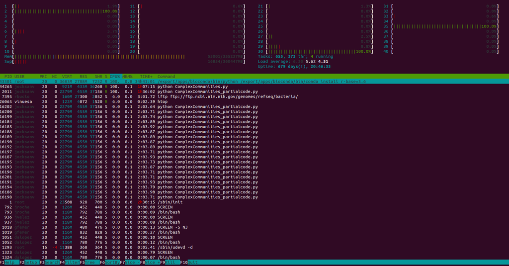

### 3.1.8 **w** mustra quien está logeado y qué está haciendo

`w`

```
 11:41:49 up 679 days, 20:42, 20 users,  load average: 3,26, 3,91, 3,79
USER     TTY      FROM              LOGIN@   IDLE   JCPU   PCPU WHAT
ati      pts/0    132.248.220.117  27Feb20 35:33m 34:36m  0.50s sshd: ati [priv]
ati      tty1     :0               21Jan19 679days  2:30m  0.40s pam: gdm-password
ati      pts/3    :0.0             21Jan19 325days  0.71s 57.47s gnome-terminal
ajhernan pts/13   132.248.220.117  06Sep20 33days  0.33s  0.33s -bash
ati      pts/22   132.248.220.117  27Feb20 11:03m 15.24s  0.50s sshd: ati [priv]
jwong    pts/27   :pts/20:S.0      30Jan19 668days  0.06s  0.06s /bin/bash
ati      pts/31   132.248.220.117  23Apr20  2days  3.71s  3.71s -bash
ehernans pts/36   pukuj            09:57    5:55   1.10s  1.00s python3
cdomingu pts/40   :pts/91:S.0      17Jul20 134days  0.15s  0.15s /bin/bash
cdomingu pts/41   :pts/91:S.1      17Jul20 134days  0.19s  0.19s /bin/bash
cdomingu pts/53   :pts/91:S.2      17Jul20 134days  0.20s  0.20s /bin/bash
cdomingu pts/57   :pts/91:S.3      17Jul20 134days  0.17s  0.17s /bin/bash
rolayo   pts/73   mosh             24Aug19 467days  0.18s  0.18s -bash
cdomingu pts/76   :pts/91:S.4      17Jul20 86days  0.36s  0.36s /bin/bash
ati      pts/82   132.248.220.117  05Oct20 11days  1.14s  1.14s -bash
cdomingu pts/91   :pts/83:S.0      17Jul20 86days  5:14   5:14  screen -r 10767.pts-13.tepeu
fcastane pts/132  :pts/133:S.0     20Aug20 100days  0.06s  0.03s SCREEN -S K12A
aescobed pts/167  pukuj            Sat12    1:54m  0.51s  0.51s -bash
vinuesa  pts/176  akbal.ccg.unam.m 10:50    1.00s  0.44s  0.14s w
rbucio   pts/179  pukuj            Sat18   42:29   2:41   0.28s sshd: rbucio [priv]
```

## 3.2 Exploración del sistema de archivos

El **sistema de archivos de GNU/Linux** tiene una estructura jerárquica de directorios y subdirectorios que penden del **directorio raíz** $/$. Esta estructura puede ser visualizada convenientemente con el comando $tree$. (Nota: $tree$ tal vez no esté instalado en tu sistema).

### 3.2.1 Imprime la estructura de directorios de tu home u otro directorio

```
tree -d $HOME/cursos/

/home/vinuesa/cursos/
└── intro2linux
    ├── bin
    ├── data
    ├── docs
    │ └── data
    ├── intro2linux
    │ ├── sesion1
    │ └── sesion1_linux
    ├── participantes_Taller_CG_FC
    ├── pics
    └── tutorials
        └── awk
```

- Nota: según el directorio que indiques, la salida puede ser copiosa. Usar con criterio. Puedes limitar el número de nivels (subdirectorios) a mostrar con -L # (Level number)

```
tree -d -L 2 $HOME/cursos/

/home/vinuesa/cursos/
└── intro2linux
    ├── bin
    ├── data
    ├── docs
    ├── intro2linux
    ├── participantes_Taller_CG_FC
    ├── pics
    └── tutorials
```

### 3.2.2 **pwd** imprime la **ruta absoluta** del directorio actual

```bash
# dónde me encuentro en el sistema?
pwd
```

```
## /home/vinuesa/cursos/intro2linux
```

### 3.2.3 **ls** lista contenidos del directorio

```bash
# Qué contiene el directorio actual?
#  => Nota: muchos comandos los preced con '| head' para listar sólo las primeras (10) líneas
#           de la salida del primer comando, con el fin de que ésta no sea demasiado larga.
#     Veremos el uso de pipes '|' en detalle más adelante.
#           Por ahora ignóralo y teclea simplemente ls
ls | head
```

```
## align_seqs_with_clustal_or_muscle.sh
## aoa.awk
## assembly_summary.txt.gz
## awkvars.out
## bash_script_template_with_getopts.sh
## bin
## blast-imager.pl
## clases_avance.txt
## compute_DNA_seq_stats.awk
## consensus_tre.nwk
```

```bash
# mostrar todos (-a all) los archivos, incluidos los ocultos, y sus propiedades
ls -al | head -20
```

```
## total 102140
## drwxr-xr-x 12 vinuesa vinuesa    20480 sep  7 14:10 .
## drwxr-xr-x  4 vinuesa vinuesa     4096 nov 11  2020 ..
## -rwxr-xr-x  1 vinuesa vinuesa     2135 oct 14  2020 align_seqs_with_clustal_or_muscle.sh
## -rw-rw-r--  1 vinuesa vinuesa      244 dic 27  2020 aoa.awk
## -rw-r--r--  1 vinuesa vinuesa  6780296 oct 20  2020 assembly_summary.txt.gz
## -rw-rw-r--  1 vinuesa vinuesa      895 dic 21  2020 awkvars.out
## -rw-r--r--  1 vinuesa vinuesa     5505 nov  7  2020 bash_script_template_with_getopts.sh
## drwxrwxr-x  2 vinuesa vinuesa     4096 nov 16  2020 bin
## -rwxr-xr-x  1 vinuesa vinuesa     5406 oct 14  2020 blast-imager.pl
## -rw-rw-r--  1 vinuesa vinuesa      933 nov  4  2020 clases_avance.txt
## -rwxr-xr-x  1 vinuesa vinuesa     1245 dic 19  2020 compute_DNA_seq_stats.awk
## -rw-rw-r--  1 vinuesa vinuesa     1335 nov 12  2020 consensus_tre.nwk
## -rw-rw-r--  1 vinuesa vinuesa     3715 dic  1  2020 count_genome_features_for_taxon.awk
## -rw-rw-r--  1 vinuesa vinuesa     3460 nov  7  2020 count_genome_features_for_taxon_V2.awk
## drwxrwxr-x  2 vinuesa vinuesa     4096 dic 29  2020 data
## -rw-rw-r--  1 vinuesa vinuesa       43 nov  4  2020 dna_string.txt
## drwxr-xr-x  2 vinuesa vinuesa     4096 nov 26  2020 docs
## -rwxr-xr-x  1 vinuesa vinuesa    21118 ene  1  2021 extract_CDSs_from_GenBank.awk
## -rwxr-xr-x  1 vinuesa vinuesa     1699 nov 28  2020 extract_DNA_string_from_genbank.awk
```

#### 3.2.3.1 Veamos el contenido del **directorio raíz /**

- corramos un $ls$ sin argumentos

```bash
ls / | head
```

```
## bin
## boot
## cdrom
## dev
## etc
## home
## lib
## lib32
## lib64
## libx32
```

- mucha más información obtenemos con el formato largo de ls: $ls -l$

```bash
ls -l / | head
```

```
## total 128
## lrwxrwxrwx   1 root root     7 oct  4  2020 bin -> usr/bin
## drwxr-xr-x   4 root root  4096 sep 23 17:12 boot
## drwxr-xr-x   2 root root  4096 oct  4  2020 cdrom
## drwxr-xr-x  21 root root  4840 sep 26 17:07 dev
## drwxr-xr-x 163 root root 12288 sep 26 17:31 etc
## drwxr-xr-x   5 root root  4096 abr 15  2020 home
## lrwxrwxrwx   1 root root     7 oct  4  2020 lib -> usr/lib
## lrwxrwxrwx   1 root root     9 oct  4  2020 lib32 -> usr/lib32
## lrwxrwxrwx   1 root root     9 oct  4  2020 lib64 -> usr/lib64
```

```bash
ls /usr/local/bin | head
```

```
## alimask
## append_sff
## asap
## bam_coverage_windows.pl
## baseml
## basemlg
## bdf2gdfont.pl
## blastall
## blastdb_aliastool
## blastdbcheck
```

```bash
# idem, pero con detalles de permisos etc
ls -l /usr/local/bin | head
```

```
## total 172288
## -rwxr-xr-x 1 root root   464848 ene 22  2021 alimask
## -rwxr-xr-x 1 root root    27376 dic  8  2020 append_sff
## -rwxr-xr-x 1 root root   144000 may  7 14:41 asap
## -r-xr-xr-x 1 root root     2941 nov  6  2021 bam_coverage_windows.pl
## lrwxrwxrwx 1 root root       47 feb 18  2021 baseml -> /home/vinuesa/soft_download/paml4.9j/bin/baseml
## lrwxrwxrwx 1 root root       48 feb 18  2021 basemlg -> /home/vinuesa/soft_download/paml4.9j/bin/basemlg
## -r-xr-xr-x 1 root root     4689 jun 19 21:24 bdf2gdfont.pl
## lrwxrwxrwx 1 root root       53 dic 31  2020 blastall -> /home/vinuesa/soft_download/blast-2.2.26/bin/blastall
## lrwxrwxrwx 1 root root       68 jul 16  2021 blastdb_aliastool -> /home/vinuesa/soft_download/ncbi-blast-2.12.0+/bin/blastdb_aliastool
```

```bash
# idem, pero ordenando los archivos por fechas de modificacion (-t), listando los mas recientes al final (-r), es decir, en orden reverso
ls -ltr /usr/local/bin | tail
```

```
## -r-xr-xr-x 1 root root     4495 jun 19 21:47 bp_seqpart
## -r-xr-xr-x 1 root root     9709 jun 19 21:49 bp_flanks
## -r-xr-xr-x 1 root root    16202 jun 19 21:50 lwp-request
## -r-xr-xr-x 1 root root     2413 jun 19 21:50 lwp-mirror
## -r-xr-xr-x 1 root root     2711 jun 19 21:50 lwp-dump
## -r-xr-xr-x 1 root root    10292 jun 19 21:50 lwp-download
## -r-xr-xr-x 1 root root    10803 jun 19 21:50 pod2text
## -r-xr-xr-x 1 root root    15034 jun 19 21:50 pod2man
## -r-xr-xr-x 1 root root    22155 jun 19 21:50 make_method
## -rwxr-xr-x 1 root root  2232640 ago 15 20:29 raxml-ng-mpi
```

### 3.2.4 Expansión de caracteres con * y **?**

```bash
# lista los archivos en /bin que empiezan por las letras b y c
ls /bin/b* | head -5
ls /bin/c* | head -5
```

```
## /bin/b2
## /bin/b2sum
## /bin/backtranambig
## /bin/backtranseq
## /bin/bamToBed
## /bin/c++
## /bin/c89
## /bin/c89-gcc
## /bin/c99
## /bin/c99-gcc
```

```bash
# lista los archivos en /bin que empiezan por la letra c seguida de uno o dos caracteres más
ls /bin/c? | head -5
ls /bin/c?? | head -5
```

```
## /bin/cc
## /bin/cp
## /bin/c++
## /bin/c89
## /bin/c99
## /bin/cai
## /bin/cal
```

### 3.2.5 Opciones más comunes e importantes del comando $ls$

Es fundamental que domines estas opciones básicas de $ls$

- **-a** list all (lista archivo ocultos tipo .directorio o .archivo)
- **-l** long format (muestra permisos y otros atributos como usuario, grupo, tamaño del archivo y fecha de modificación)
- **-t** time sort (ordena por tiempo)
- **-r** reverse sort
- **-R** list subdirectories recursively
- **-S** size sort (ordena por tamaño)
- **-h** human readable (indica Kb, Mb, Gb …)

### 3.2.6 Ejemplos de opciones del comando $ls$

Recuerda que podemos indicar múltiples opciones usando un solo guión y que el orden de las opciones no importa.

Es decir `ls -la` == `ls -l -a` ==

```
ls -a
-l
```

Prueba los siguientes comandos y aprende bien estas opciones básicas de $ls$

- `ls -a`
- `ls -lt`
- `ls -ltr`
- `ls -altrh`
- `ls -lS`
- `ls -lh`

## 3.3 **Permisos** (modo de un archivo)

Los sistemas UNIX y GNU/Linux, al contrario que los basados en MS-DOS, están diseñados desde un inicio para operar en modo **multiusuario** y **multitarea** (multitasking). Por ello el sistema operativo debe asegurar la privacidad de los archivos y directorios de cada usuario del sistema.

### 3.3.1 Usuario, grupo y resto del mundo (User, Group, Others …) y permisos $rwx$

En sistemas UNIX y GNU/Linux cada archivo y directorio tiene unos permisos determinados de **lectura=$r$** **escritura=$w$** y **ejecución=$x$** para el usuario, grupo y resto del mundo, asignados en ese orden (UGO).

Un **archivo regular**, escrito por el usuario tiene los siguientes permisos por defecto, como muestra el comando $ls -l$

```
ls -l | grep odp
-rw-r--r-- 1 vinuesa vinuesa 2993606 sep 30 10:52 intro_biocomputo_Linux_LCG.odp
```

Veamos lo que quiere decir. Para ello necesitamos separar la cadena de caracteres en los siguientes componentes

```
   U   G   O       usuario grupo
1  2   3   4  5    6       7
-|rw-|r--|r-- 1 vinuesa vinuesa
```

donde:

```
1. la posición 1 (-) indica que se trata de un archivo regular. Un directorio se indica con "d" y una liga simbólica con "l"
2. El grupo 2,3 y 4 de caraceres indican el "modo" del archivo (permisos) para el usuario (U), grupo (G) y otros (resto del mundo O),
   separados por "|" para facilitar su visualización.
   En este caso el usuario tiene permisos de lectura (r) y escritura (w) sobre el archivo que no es ejecutable (-)
   El grupo y el resto del mundo sólo pueden leer el archivo, pero no modificarlo.
```

Un **directorio** generado por el usuario con el comando estándar $mkdir$ tiene los siguientes permisos por defecto, como muestra el comando $ls -l$

```
ls -l | grep intro
drwxr-xr-x 4 vinuesa vinuesa    4096 sep 29 22:56 intro2linux
```

- Ejercicio: lista los permisos (modo) de este directorio para U|G|O

### 3.3.2 Tabla de atributos de los permisos

La siguiente tabla resume los atributos que tienen los permisos $r$, $w$, $x$ sobre archivos regulares y directorios:

| Atributo | Archivos | Directorios |
| --- | --- | --- |
| r | abrir y leer | listar contenidos si tiene +x |
| w | editar pero no renombrar/borrar (atributo dir) | permite generar archivos en dir, si tiene +x |
| x | permite ejecutra archivo (programa) si +r | permite entrar al directorio |

### 3.3.3 **chmod** - cambiar el modo (permisos) de un archivo o directorio

Hay dos maneras de hacerlo:

1. Usando **notación simbólica** para U|G|O y todos (a)

| Símbolo | Significado |
| --- | --- |
| u | usuario, el dueño del archivo o directorio |
| g | dueño del gruop |
| o | otros (resto del mundo) |
| a | todos (all); combinación de u,g,o |

- Ejemplos

$chmod\ notación\ archivo|dir$

| Notación | Significado |
| --- | --- |
| u+x | da permiso de ejecución a usuario |
| u-x | revoca permiso de ejecución a usuario |
| o-r | otros (resto del mundo) no puede leer |
| +x | equivale a a+x |
| o-rw | quitar a otros permisos de rw |
| u+x,go=-rx | asignar +x a U, revocar a O permisos de rx |

$chmod\ a+rx\ script.sh$ hace el archivo script.sh leíble y ejecutable para todos

2. Usando **representación octal**

Los sistemas de numeración $octal$ (base 8) y su primo el $hexadecimal$ (base 16) se usan frecuentemente para expresar números en computadoras.

Los humanos usamos el sistama $decimal$ ya que (la mayoría) tenemos 10 dedos. Las computadoras en cambio “nacieron con un solo dedo”, por lo que cuentan usando el sistema $binario$ (base 2) usando sólo 1s y 0s. Por tanto en binario, contamos así: 0,1, 10,11, 100,101, 110,111 …

En $octal$, contamos así: 0,1,2,3,4,5,6,7, 10,11,12,13,14,15,16,17, 20,21 …

Usando una cadena de tres dígitos octales, podemos de manera muy conveniente definir el modo de un archivo para U|G|O acorde a la siguiente tabla

| octal | binario | modo del archivo |
| --- | --- | --- |
| 0 | 000 | — |
| 1 | 001 | –x |
| 2 | 010 | -w- |
| 3 | 011 | -wx |
| 4 | 100 | r– |
| 5 | 101 | r-x |
| 6 | 110 | rw- |
| 7 | 111 | rwx |

De modo que combinando los octales

**READ = 4**

**WRITE = 2**

**EXECUTE = 1**

con las posiciones U|G|O, define los modos:

| USER | GROUP | OTHERS | MODE |
| --- | --- | --- | --- |
| r w x | r w x | r w x | UGO |
| 4 2 0 | 0 0 0 | 0 0 0 | 600 |
| 4 2 1 | 4 0 1 | 4 0 1 | 755 |

- Ejemplos
  - $chmod\ 755\ script.sh$ otorga a “script.sh” modo de: -rwxr-xr-x
  - $chmod\ 700\ script.sh$ otorga a “script.sh” modo de: -rwx——
  - $chmod\ 644\ script.sh$ otorga a “script.sh” modo de: -rw-r–r–

### 3.3.4 **file** nos indica las propiedades de un archivo

```bash
# mostrar las características de los archivos con file
file assembly_summary.txt.gz
file linux_commands.tab
file intro2linux
```

```
## assembly_summary.txt.gz: gzip compressed data, was "assembly_summary.txt", last modified: Mon Jul 22 00:26:11 2019, from Unix, original size modulo 2^32 48497020
## linux_commands.tab: symbolic link to /home/vinuesa/Cursos/TIB/TIB19-T3/sesion1_intro2linux/linux_basic_commands.tab
## intro2linux: directory
```

## 3.4 Moviéndonos por el sistema de archivos: comando **cd**

Para movernos por el sistema de archivos de un sistema Linux podemos hacer uso de la **ruta absoluta** o la **ruta relativa**.

### 3.4.1 La **ruta absoluta**

Define la ruta a cualquier directorio o archivo en el sistema partiendo del **directorio raíz** $/$, como indica el comando $pwd$

#### 3.4.1.1 de nuevo, ¿dónde estoy?: imprime directorio actual con **pwd**

```bash
pwd
```

```
## /home/vinuesa/cursos/intro2linux
```

#### 3.4.1.2 entra a un directorio cualquiera usando la ruta absoluta

```
# indicamos la ruta absoluta o "path" al directorio al que queremos entrar
cd /home/vinuesa/cursos/intro2linux/data
```

### 3.4.2 La **ruta relativa**

Se define en relación al directorio actual en el que estás.

#### 3.4.2.1 entra a un subdirectorio bajo en directorio actual usando la ruta relativa

```
cd directorio
```

#### 3.4.2.2 sube un nivel de directorio usando RUTA RELATIVA: **cd ..**

```bash
cd ..
```

#### 3.4.2.3 sube dos niveles en la jerarquía de directorios usando RUTA RELATIVA: **cd ../..**

```bash
cd ../..
```

- ¿dónde estoy?

```bash
pwd
```

```
## /home/vinuesa/cursos/intro2linux
```

#### 3.4.2.4 regresa al directorio en el que estabas justo antes con **cd -**

```bash
cd -
pwd
```

```
## /home/vinuesa/Cursos/intro_biocomp4genomics_TFC
## /home/vinuesa/Cursos/intro_biocomp4genomics_TFC
```

#### 3.4.2.5 regresa a tu home desde cualquier punto del sistema de archivos con **cd**

```bash
cd $HOME

# que es equivalente a:
cd ~

# o también a
cd
```

- cd cambiar directorios con rutas absolutas **(/ruta/completa/al/dir) y relativas ../../**

```bash
# a dónde nos lleva este comando?
cd /
pwd
```

```
## /
```

- cambia de nuevo a tu home

```bash
cd -
pwd
```

```
## /home/vinuesa/Cursos/intro_biocomp4genomics_TFC
## /home/vinuesa/Cursos/intro_biocomp4genomics_TFC
```

- sube al directorio home/ usando la ruta relativa

```bash
cd ../
```

- y lista los contenidos

```bash
ls | head
```

```
## align_seqs_with_clustal_or_muscle.sh
## aoa.awk
## assembly_summary.txt.gz
## awkvars.out
## bash_script_template_with_getopts.sh
## bin
## blast-imager.pl
## clases_avance.txt
## compute_DNA_seq_stats.awk
## consensus_tre.nwk
```

## 3.5 Generación de directorios: comando **mkdir**

```bash
# vamos a $HOME y generamos el directorio intro2linux
cd
if [ -d intro2linux ]; then
    echo "found dir intro2linux"
else
    mkdir intro2linux
fi
```

```
## found dir intro2linux
```

- comprueba los **permisos** del nuevo directorio

```bash
ls -ld intro2linux
```

```
## drwxr-xr-x 4 vinuesa vinuesa 4096 sep 29  2020 intro2linux
```

- generemos un subdirectorio por debajo del que acabamos de crear:

```bash
mkdir -p intro2linux/sesion1 && cd intro2linux/sesion1
```

[output not shown]

- cambiamos a /home/vinuesa e intenta crear estos mismos directorios ahí

```bash
cd /home/vinuesa && mkdir -p intro2linux/sesion1
```

No puedes escribir en mi directorio, porque no te he otorgado permiso para ello ;)

## 3.6 Qué es exactamente un $comando$ en GNU/Linux?

Un comando de GNU/Linux puede ser una de cuatro cosas:

1. un **programa ejecutable**, como los que hemos estado usando, tales como $cut$, $sort$, $grep$ … que están guardados en directorios del sistame tales como $/bin$, $/usr/bin$ … Estos son *programas compilados*, escritos en lenguajes como $C$ o $C++$. Pero un comando también puede ser un *script* escrito en un lenguaje interpretado como $Bash$, $Perl$, $Phython$ o $R$, posiblemente escrito por el propio usuario. Estos frecuentemente se ubican en el directorio *$HOME/bin*
2. puede ser un **comando del shell**, un “$shell\ builtin$”, como $cd$, $cp$ …
3. una **función de shell**. Estos son miniprogramas de shell exportadas al ambiente (environment). Veremos más adelante cómo se delcaran funciones.
4. un **alias**, es decir un nombre de nuestra elección para otro comando.

### 3.6.1 Genera tu propio comando con un **alias**

El shell provee el comando integrado (“builtin”) $alias$ que es muy útil para simplificar la llamada a comandos complejos que repetimos con frecuencia.

La sintaxis es la siguiente `alias NOMBRE=“COMANDO”`

Es importante asegurarse que el nombre del alias no existe previamente en el sistema. Antes de generarlo, tecleo $tep$ en la consola para asegurarme que no existe un comando con dicho nombre.

```
vinuesa@alisio:~$ tep
-bash: tep: command not found
```

Ahora puedo generar el alias $tep$ para conectarme al servidor tepeu:

```
# Nota: uso asteriscos para no hacer público el NIS completo del server
alias tep="ssh -X vinuesa@tepeu.*.*.*"
```

Noten que el uso de comillas dobles encerrando el comando para el cual vamos a generar un *alias*

Una vez generado, puedo teclear $tep$, que me permite conectarme al servidor.

```
vinuesa@alisio:~$ tep
vinuesa@132.*.*.*'s password:
```

#### 3.6.1.1 El archivo **$HOME/.bash_aliases**

Si quieres guardar una lista personal de aliases de manera permanente, puedes escribirlos en el archivo $\$HOME/.bash\_aliases$, *uno de los archivos de configuración del ambiente* que los usuarios avanzados de GNU/Linux guardan en su $\$HOME$

Cada vez que inicias tu máquina o que estableces una sesión remota, se lee este archivo en memoria, quedando los aliases como parte del *ambiente* ($environment$).

Van unas líneas de mi archivo $\$HOME/.bash\_aliases$ como ejemplos (los asteriscos los pongo para no hacer públicas las IPs)

```
# ssh aliases
alias puma="ssh -X vinuesa@132.*.*.*"            # desktop
alias ix="ssh -X vinuesa@132.*.*.*"              # ixchel ubuntu Linux server
alias tep="ssh -X vinuesa@132.*.*.*"             # tepeu Linux server

# fetch (sftp) data from servers
alias fyax="echo 'sftp vinuesa@*.*.unam.mx:'"
alias fku="echo 'sftp vinuesa@*.*.unam.mx:'"

# aliases for Java utils
alias figtree="java -Xms128m -Xmx512m -jar /home/vinuesa/soft_download/FigTree_v1.4.4/lib/figtree.jar"
alias seaview="/home/vinuesa/soft_download/seaview/seaview"

...
```

El archivo $\$HOME/.bash_aliases$ es leído por los archivos de configuración $\$HOME/.bashrc$ cuando iniciamos nuestra máquina local, o $\$HOME/.bash\_profile$ cuando establecemos una sesión remota vía $ssh$. Hablaremos más de estos archivo en la sección de administración básica de un sistema Linux.

Como ejercicio te sugiero que busques y leas estos archivos. Recuerda que tienes que usar $ls\ -a$ para poderlos ver, ya que el nombre de archivo está precedido por un **.** para ocultarlos a una llamada de $ls$ estándar.

### 3.6.2 Identificación del tipo de comando con **type**

Podemos identificar a cuál de las cuatro categorías arriba listadas pertenece un comando particular. Veamos unos ejemplos:

```bash
type grep
type alias
```

```
## grep is /usr/bin/grep
## alias is a shell builtin
```

### 3.6.3 Muestra la ruta del comando con **which**

Recuerda, podemos tener diferentes versiones de un mismo comando en diferentes directorios del sistema. El comando $which$ nos permite identificar la ruta absoluta del que primero ve el sistema en el $PATH$

```bash
which blastn
which perl
which trunc_seq.pl
which transpose_pangenome_matrix.sh
```

```
## /usr/local/bin/blastn
## /usr/bin/perl
## /home/vinuesa/bin/trunc_seq.pl
## /home/vinuesa/bin/transpose_pangenome_matrix.sh
```

### 3.6.4 Manual de cada comando: **man command**

La mayoría de los programas ejecutables del sistema proveen un formato estandarizado de documentación que se despliega en la consola usando la línea de comandos

```bash
# mira las opciones de cut y sort en la manpage
man cut | head -30
```

```
## CUT(1)                                                                                    User Commands                                                                                    CUT(1)
##
## NAME
##        cut - remove sections from each line of files
##
## SYNOPSIS
##        cut OPTION... [FILE]...
##
## DESCRIPTION
##        Print selected parts of lines from each FILE to standard output.
##
##        With no FILE, or when FILE is -, read standard input.
##
##        Mandatory arguments to long options are mandatory for short options too.
##
##        -b, --bytes=LIST
##               select only these bytes
##
##        -c, --characters=LIST
##               select only these characters
##
##        -d, --delimiter=DELIM
##               use DELIM instead of TAB for field delimiter
##
##        -f, --fields=LIST
##               select only these fields;  also print any line that contains no delimiter character, unless the -s option is specified
##
##        -n     (ignored)
##
##        --complement
```

### 3.6.5 Ayuda de cada comando integrado en el Shell: **help shell_builtin** para *shell builtins*

```bash
# mira las opciones de cut y sort en la manpage
help cd
```

```
## cd: cd [-L|[-P [-e]] [-@]] [dir]
##     Change the shell working directory.
##
##     Change the current directory to DIR.  The default DIR is the value of the
##     HOME shell variable.
##
##     The variable CDPATH defines the search path for the directory containing
##     DIR.  Alternative directory names in CDPATH are separated by a colon (:).
##     A null directory name is the same as the current directory.  If DIR begins
##     with a slash (/), then CDPATH is not used.
##
##     If the directory is not found, and the shell option `cdable_vars' is set,
##     the word is assumed to be  a variable name.  If that variable has a value,
##     its value is used for DIR.
##
##     Options:
##       -L force symbolic links to be followed: resolve symbolic
##          links in DIR after processing instances of `..'
##       -P use the physical directory structure without following
##          symbolic links: resolve symbolic links in DIR before
##          processing instances of `..'
##       -e if the -P option is supplied, and the current working
##          directory cannot be determined successfully, exit with
##          a non-zero status
##       -@ on systems that support it, present a file with extended
##          attributes as a directory containing the file attributes
##
##     The default is to follow symbolic links, as if `-L' were specified.
##     `..' is processed by removing the immediately previous pathname component
##     back to a slash or the beginning of DIR.
##
##     Exit Status:
##     Returns 0 if the directory is changed, and if $PWD is set successfully when
##     -P is used; non-zero otherwise.
```

### 3.6.6 Despliega información básica de uso del comando: **command –help**

Muchos programas del sistema soportan la opción $--help$ que despliega la descripción de la sintaxis del comando y las opciones. Esta suele ser una descripción más corta que la que nos dan las páginas de $man$ para el comando

```bash
# mira las opciones de cut y sort en la manpage
mkdir --help
```

```
## Usage: mkdir [OPTION]... DIRECTORY...
## Create the DIRECTORY(ies), if they do not already exist.
##
## Mandatory arguments to long options are mandatory for short options too.
##   -m, --mode=MODE   set file mode (as in chmod), not a=rwx - umask
##   -p, --parents     no error if existing, make parent directories as needed
##   -v, --verbose     print a message for each created directory
##   -Z                   set SELinux security context of each created directory
##                          to the default type
##       --context[=CTX]  like -Z, or if CTX is specified then set the SELinux
##                          or SMACK security context to CTX
##       --help     display this help and exit
##       --version  output version information and exit
##
## GNU coreutils online help: <https://www.gnu.org/software/coreutils/>
## Full documentation at: <https://www.gnu.org/software/coreutils/mkdir>
## or available locally via: info '(coreutils) mkdir invocation'
```

### 3.6.7 Encuentra comandos adecuados para un tipo de acción: **apropos**

Por ejemplo, quiero saber qué distribución de Linux corre mi máquina, pero no recuerdo el comando.

```bash
# encuentra comandos que tienen que ver con la palabra clave distribution
apropos distribution
```

```
## Alien::Base::Authoring (3pm) - Authoring an Alien distribution using Alien::Base
## Bio::Tools::RandomDistFunctions (3pm) - A set of routines useful for generating random data in different distributions
## hmmsim (1)           - collect profile score distributions on random sequences
## Linux::Distribution (3pm) - Perl extension to detect on which Linux distribution we are running.
## Math::GSL::CDF (3pm) - Cumulative Distribution Functions
## Math::GSL::Randist (3pm) - Probability Distributions
## Module::Build::Bundling (3pm) - How to bundle Module::Build with a distribution
## Module::Build::Notes (3pm) - Create persistent distribution configuration modules
## Module::CPANTS::Analyse (3pm) - Generate Kwalitee ratings for a distribution
## Module::CPANTS::Kwalitee::Distros (3pm) - Information retrieved from the various Linux and other distributions
## Package::DeprecationManager (3pm) - Manage deprecation warnings for your distribution
## Parse::Distname (3pm) - parse a distribution name
## Test2::Suite (3pm)   - Distribution with a rich set of tools built upon the Test2 framework.
## Test::CPAN::Meta::JSON (3pm) - Validate a META.json file within a CPAN distribution.
## Test::File::ShareDir::Object::Dist (3pm) - Object Oriented ShareDir creation for distributions
## Test::Kwalitee (3pm) - Test the Kwalitee of a distribution before you release it
## Test::Pod::Coverage (3pm) - Check for pod coverage in your distribution.
## bdftopcf (1)         - convert X font from Bitmap Distribution Format to Portable Compiled Format
## CPAN::DistnameInfo (3pm) - Extract distribution name and version from a distribution filename
## CPAN::Meta (3perl)   - the distribution metadata for a CPAN dist
## CPAN::Meta::Converter (3perl) - Convert CPAN distribution metadata structures
## CPAN::Meta::Feature (3perl) - an optional feature provided by a CPAN distribution
## CPAN::Meta::Prereqs (3perl) - a set of distribution prerequisites by phase and type
## CPAN::Meta::Spec (3perl) - specification for CPAN distribution metadata
## CPAN::Meta::Validator (3perl) - validate CPAN distribution metadata structures
## debian-distro-info (1) - provides information about Debian's distributions
## distro-info (1)      - provides information about the distributions' releases
## dpkg-vendor (1)      - queries information about distribution vendors
## gsl-randist (1)      - generate random samples from various distributions
## iptables-extensions (8) - list of extensions in the standard iptables distribution
## lsb_release (1)      - print distribution-specific information
## perlnewmod (1)       - preparing a new module for distribution
## perlutil (1)         - utilities packaged with the Perl distribution
## pfscale (1)          - fit parameters of an extreme-value distribution to a profile score list
## Test::CPAN::Changes (3pm) - Validation of the Changes file in a CPAN distribution
## ubuntu-distro-info (1) - provides information about Ubuntu's distributions
```

- veo que es lsb_release. Consultemos su $--help$

```bash
# primero consulto su ayuda
lsb_release --help
```

```
## Usage: lsb_release [options]
##
## Options:
##   -h, --help         show this help message and exit
##   -v, --version      show LSB modules this system supports
##   -i, --id           show distributor ID
##   -d, --description  show description of this distribution
##   -r, --release      show release number of this distribution
##   -c, --codename     show code name of this distribution
##   -a, --all          show all of the above information
##   -s, --short        show requested information in short format
```

- ahora ejecuto el comando con la opción deseada

```bash
lsb_release -a
```

```
## No LSB modules are available.
## Distributor ID:  Ubuntu
## Description: Ubuntu 20.04.5 LTS
## Release: 20.04
## Codename:    focal
```

### 3.6.8 Imprime desripciones de una línea de un comando con: **whatis**

Si no recuerdas o sabes lo que hace un comando particular, puedes obtener una respuesta rápida con $whatis\ command$

```bash
whatis cron
```

```
## cron (8)             - daemon to execute scheduled commands (Vixie Cron)
## cron (3tcl)          - Tool for automating the period callback of commands
```

# 4 Trabajando con archivos: copiar, mover, renombrar y borrar archivos

```bash
# cambia a tu home, y luego a intro2linux/sesion1
cd && cd intro2linux/sesion1
```

[output not shown]

## 4.1 copia de archivo simple: **cp /path/to/file .**

- copia el archivo /home/vinuesa/intro2linux/data/linux_basic_commands.tab al directorio actual

```
cp /home/vinuesa/intro2linux/data/linux_basic_commands.tab . # <<< vean el punto, significa, dir actual
```

- otra manera, usando **rutas absolutas** y la **variable de ambiente $HOME**

```
cp /home/vinuesa/intro2linux/data/linux_basic_commands.tab $HOME/intro2linux/sesion1/
```

- otra variante, usando **rutas absolutas** y la tilde $~$ como abreviación de **$HOME**

```
cp /home/vinuesa/intro2linux/data/linux_basic_commands.tab ~/intro2linux/sesion1/
```

- copia un archivo a otro directorio renombrando la copia

```
cp ~/tmp/working_with_linux_commands.html ~/cursos/docs/index.html
```

## 4.2 copiar un directorio: **cp -r dir .** [-r recursively, el directorio y su contenido]

- copiar el directorio /home/vinuesa/intro2linux/data/ a tu dir actual

```
# Noten el punto '.' y cp -r (recursively), necesario para copiar directorios completos
cp -r /home/vinuesa/intro2linux/data/ .
```

- NOTA: podemos hacer uso de las combinaciones de ruta absoluta y/o relativas que más nos convengan.

## 4.3 Eliminar un directorio: **rm -r[f]** [recursively -r and force -f]

```bash
mkdir borrame

cp linux_basic_commands.tab borrame

ls borrame

rm -rf borrame
```

```
## linux_basic_commands.tab
```

Prueba ahora este comando

```
rm data
```

qué pasa?

¿Cómo tengo que borrar un directorio?

```
rm -r[f]
directorio
```

```
rm -rf data
```

- NOTA: en algunos sistemas la llamada a $rm\ -r\ directorio$ no permite borrar $directorio$ directamente, imprimiendo un mensaje de error. Par forzar el borrado, si el mensaje de advertencia, usamos $rm\ -rf\ directorio$

## 4.4 **scp** copia de archivos entre máquinas vía Internet

Para llevar/copiar un archivo de tu máquina local al servidor, usamos el comando $scp$

Sintaxis: `scp ARCHIVO_LOCAL USUARIO@ip.maquina:/home/USUARIO/ruta/al/dir/destino/`

- **Ejercicio** con $scp$
  1. descarga el archivo linux_basic_commands.tab del repositorio GitHub a tu máquina
  2. cópialo a tu $\$HOME$ en el servidor

```
# asegúrate de estar en el directorio que contiene el archvo descargado:
ls linux_basic_commands.tab

scp linux_basic_commands.tab USUARIO@ip.maquina:/home/USUARIO/ruta/al/dir/destino/
```

- **NOTAS sobre scp**:
1. Si queremos copiar un directorio podemos usar la sintaxis

   ```
   scp
   -r dir USUARIO@ip.maquina:/home/USUARIO/ruta/al/dir/destino/
   ```

2. Usa `scp -r dir destino` sólo si $dir$ contiene pocos archivos pequeños.
3. Si necesitas copiar archivos grandes o directorios con muchos archivos, comprímelos primero con $gzip$ y $tar$ (ver más adelante)

## 4.5 **sftp** descarga de archivos de una máquina remota a tu máquina local (laptop o desktop)

Para traer/copiar un archivo del servidor al directorio actual en la máquina local, usamos el comando $sftp$

Sintaxis: `sftp USUARIO@ip.maquina:/home/USUARIO/ruta/al/dir/destino/`

```
# asegúrate de estar en el directorio de tu máquina local donde quieres depositar el archivo a descargar del servidor:

cd $HOME/ruta/dir/destino

# ahora establecemos una sesión de ftp segura (sftp) a la máquina remoata
sftp USUARIO@ip.maquina:/home/USUARIO/ruta/al/dir/destino/

# podemos hacer un ls para buscar el/los archivo(s) que queremos descargar
ls *tab

# con la orden get, recuperamos los archivos deseados
get linux_basic_commands.tab
get *tab
get -r directorio

# cerrar la sesión sftp al serivdor
quit

# ésto nos regresa a $HOME/ruta/dir/destino
ls
```

- **Ejercicio** con $sftp$
  1. genera el directorio *tmp_sftp* en tu máquina y métete en él
  2. copia de tepeu el archivo de tu elección a *tmp_sftp* meditante $sftp$

## 4.6 Generación de ligas simbólicas a archivos: comando **ln -s /ruta/al/archivo/fuente nombre_liga**

Hacer ligas simbólicas en vez de copiar cada archivo es muy importante, ya que permite ahorrar mucho espacio en disco al evitar la multiplicación de copias fisicas en el disco duro del mismo archivo en el $HOME de uno o más usuarios.

Sintaxis básica:

- `ln -s /path/to/file .` # que genera una liga simbólica a /path/to/file, llamada file, en el directorio de trabajo
- `ln -s /path/to/file nombre_nuevo` # que genera una liga simbólica a /path/to/file, llamada nombre_nuevo, en el directorio de trabajo
- `ln -s /path/to/dir_with_many_files/*fastq.gz .` # que genera una liga simbólica en el directorio actual para cada archivo fastq.gz ubicado en /path/to/dir_with_many_files

```bash
hostn=$(hostname)
if [ "$hostn" == "alisio" ]; then
  ln -s /home/vinuesa/Cursos/TIB/TIB19-T3/sesion1_intro2linux/linux_basic_commands.tab comandos_de_linux.tab
elif [ "$hostn" == "puma" ]; then
  ln -s /home/vinuesa/Cursos/TIB19-T3/sesion1_intro2linux/linux_basic_commands.tab comandos_de_linux.tab
elif [ "$hostn" == "tepeu" ]; then
   ln -s /home/vinuesa/intro2linux/data/linux_basic_commands.tab comandos_de_linux.tab
   ln -s /home/vinuesa/intro2linux/data/assembly_summary.txt.gz .
fi

# confirmamos que se generaron las ligas
ls -l | head
```

```
## total 102112
## -rwxr-xr-x 1 vinuesa vinuesa     2135 oct 14  2020 align_seqs_with_clustal_or_muscle.sh
## -rw-rw-r-- 1 vinuesa vinuesa      244 dic 27  2020 aoa.awk
## -rw-r--r-- 1 vinuesa vinuesa  6780296 oct 20  2020 assembly_summary.txt.gz
## -rw-rw-r-- 1 vinuesa vinuesa      895 dic 21  2020 awkvars.out
## -rw-r--r-- 1 vinuesa vinuesa     5505 nov  7  2020 bash_script_template_with_getopts.sh
## drwxrwxr-x 2 vinuesa vinuesa     4096 nov 16  2020 bin
## -rwxr-xr-x 1 vinuesa vinuesa     5406 oct 14  2020 blast-imager.pl
## -rw-rw-r-- 1 vinuesa vinuesa      933 nov  4  2020 clases_avance.txt
## lrwxrwxrwx 1 vinuesa vinuesa       78 sep 26 22:11 comandos_de_linux.tab -> /home/vinuesa/Cursos/TIB/TIB19-T3/sesion1_intro2linux/linux_basic_commands.tab
```

- renombramos la liga (o cualquier archivo o directorio)

```bash
  mv comandos_de_linux.tab linux_commands.tab
```

- podemos elegir el nombre del apuntador que nos convenga

```
  ln -s nombre_largo_de_archivo.tgz arch_tmp.tgz
```

- podemos generar ligas simbólicas a todos los archivos de un directorio (por ej. lecturas *fastq* comprimidas de un secuenciador Illumina) en el directorio de trabajo (actual) con un comando como éste:

```
  ln -s /export/data3/illumina_reads/run_stenos_2020-10-14/*fastq.gz .
```

## 4.7 Nombres de archivos y directorios y uso de comillas sencillas y dobles

En las versiones modernas de GNU/Linux, los nombres de archivos con espacios son automáticamente mostrados entre comillas sencillas: ‘mi archivo de secuencias.fasta’. Así el $Shell$ considera el nombre del archivo como un solo argumento.

### 4.7.1 Uso de **comillas sencillas($'$)**: interpretación literal y escape de caracteres reservados para el *SHELL*

- Para renombrar o copiar un archivo que contiene espacies, debes escaparlo con comillar sencillas ($'$)

En el siguiente ejemplo las comillas sencillas sireven para interpretar literalmente los espacios como caracteres, por lo que el nombre de archivo es visto por el comando $mv$ como un solo argumento

```
mv 'mi archivo de secuencias.fasta' recA_Bradyrhizobium.fna
```

En ciertas ocasiones usarás **comillas sencillas ($'$)** para la ejecución de algunos programas desde la línea de comandos como por ejemplo al pasar opciones complejas a sed, perl, awk … Estos son lenguajes interpretados, cuyo uso básico veremos más adelante

- Ejemplo de llamada del comando $rename$ para eliminar espacios en nombres de archivos y directorios

```
# rename es un script de Perl que permite renombrar archivos de manera muy eficiente
#   haciendo uso de expresiones regulares y expansión de nombres de archivo
# El siguiente ejemplo renombra todos los archivos docx del directorio,
#   cabmiando todas las instancias (globalmente) de espacios por guiones bajos
rename 's/ /_/g' *.docx
```

- Ejemplo de llamada a $sed$

```
# con esta sentencia el editor de flujo sed cambiará todas las instancias de Windos por GNU-Linux
#  que aparecen en el archivo txt
sed 's/Windows/GNU-Linux/g' archivo.txt # cambia Windows por GNU-Linux globalmente ;)
```

### 4.7.2 Uso de **comillas dobles ($"$)** para interpolación de variables

Se requieren **comillas dobles ($"$)** siempre que queramos interpolar una variable (obtener su valor) contenida dentro de una cadena de texto, como muestra el siguiente ejemplo

```bash
# echo imprime el contenido de la cadena acotada entre comillas dobles, interpolando las variables que tenga
echo "soy el usuario $USER en la máquina $HOSTNAME"
```

```
## soy el usuario vinuesa en la máquina alisio
```

Si usáramos comillas sencillas, las variables no se interpolan y se imprime literalmente el nombre de las mismas

```bash
echo 'soy el usuario $USER en la máquina $HOSTNAME'
```

```
## soy el usuario $USER en la máquina $HOSTNAME
```

# 5 Trabajando con archivos: visualización, generación y edición de archivos de texto plano (codificación ASCII)

Linux ofrece una amplia gama de programas para visualizar y editar archivos, todos con opciones poderosas y muy útiles. La elección de uno de ellos depende de lo que necesitamos o queremos.

## 5.1 Visualización de contenidos de archivos: comandos **head**, **tail**, **cat**, **less**, **more**

Los comandos $head$, $tail$, $cat$, $less$ y $more$ son algunos de los disponibles para visualizar el contenido de un archivo ASCII.

### 5.1.1 Usa **head** y **tail** para desplegar la cabecera y cola de archivos

```bash
head linux_commands.tab
```

```
## IEEE Std 1003.1-2008 utilities Name  Category    Description     First appeared
## admin    SCCS    Create and administer SCCS files    PWB UNIX
## alias    Misc    Define or display aliases
## ar   Misc    Create and maintain library archives    Version 1 AT&T UNIX
## asa  Text processing     Interpret carriage-control characters   System V
## at   Process management  Execute commands at a later time    Version 7 AT&T UNIX
## awk  Text processing     Pattern scanning and processing language    Version 7 AT&T UNIX
## basename     Filesystem  Return non-directory portion of a pathname; see also dirname    Version 7 AT&T UNIX
## batch    Process management  Schedule commands to be executed in a batch queue
## bc   Misc    Arbitrary-precision arithmetic language     Version 6 AT&T UNIX
```

```bash
tail linux_commands.tab
```

```
## val  SCCS    Validate SCCS files     System III
## vi   Text processing     Screen-oriented (visual) display editor     1BSD
## wait     Process management  Await process completion    Version 4 AT&T UNIX
## wc   Text processing     Line, word and byte or character count  Version 1 AT&T UNIX
## what     SCCS    Identify SCCS files     PWB UNIX
## who  System administration   Display who is on the system    Version 1 AT&T UNIX
## write    Misc    Write to another user's terminal    Version 1 AT&T UNIX
## xargs    Shell programming   Construct argument lists and invoke utility     PWB UNIX
## yacc     C programming   Yet another compiler compiler   PWB UNIX
## zcat     Text processing     Expand and concatenate data     4.3BSD
```

- Por defecto, $head$ y $tail$ despliegan 10 líneas. Pero podemos pasarle como opción el número de líneas deseado con esta sintaxis:

`tail -n -íntegro archivo` o simplemente con:

```
tail
-íntegro archivo
```

como se muestra en esto ejemplos:

```bash
# le podemos indicar el numero de lineas a desplegar
head -3 linux_commands.tab
```

```
## IEEE Std 1003.1-2008 utilities Name  Category    Description     First appeared
## admin    SCCS    Create and administer SCCS files    PWB UNIX
## alias    Misc    Define or display aliases
```

```bash
tail -1 linux_commands.tab
```

```
## zcat     Text processing     Expand and concatenate data     4.3BSD
```

- $tail$ tiene otras dos opciones que uso frecuentemente:
  - `tail -n +íntegro archivo` # para imprimir a partir de la fila número **-n +íntegro** (permite eliminar primeras líneas)
  - `tail -f archivo` # opción **follow**, que permite ver cómo crece la cola de un archivo a medida que se va escribiendo.

Ejemplo de `tail -n +íntegro archivo`

```bash
# imprime a partir de la línea 2, es decir, elimina cabecera del archivo
tail -n +2 linux_commands.tab | head -2
```

```
## admin    SCCS    Create and administer SCCS files    PWB UNIX
## alias    Misc    Define or display aliases
```

### 5.1.2 **cat** despliega uno o más archivos, concatenándolos si son varios

```bash
cat linux_commands.tab | head
```

```
## IEEE Std 1003.1-2008 utilities Name  Category    Description     First appeared
## admin    SCCS    Create and administer SCCS files    PWB UNIX
## alias    Misc    Define or display aliases
## ar   Misc    Create and maintain library archives    Version 1 AT&T UNIX
## asa  Text processing     Interpret carriage-control characters   System V
## at   Process management  Execute commands at a later time    Version 7 AT&T UNIX
## awk  Text processing     Pattern scanning and processing language    Version 7 AT&T UNIX
## basename     Filesystem  Return non-directory portion of a pathname; see also dirname    Version 7 AT&T UNIX
## batch    Process management  Schedule commands to be executed in a batch queue
## bc   Misc    Arbitrary-precision arithmetic language     Version 6 AT&T UNIX
```

**cat -n** nos permite añadir números de línea a los archivos desplegados

```bash
cat -n linux_commands.tab | head
```

```
##      1   IEEE Std 1003.1-2008 utilities Name     Category    Description     First appeared
##      2   admin   SCCS    Create and administer SCCS files    PWB UNIX
##      3   alias   Misc    Define or display aliases
##      4   ar  Misc    Create and maintain library archives    Version 1 AT&T UNIX
##      5   asa     Text processing     Interpret carriage-control characters   System V
##      6   at  Process management  Execute commands at a later time    Version 7 AT&T UNIX
##      7   awk     Text processing     Pattern scanning and processing language    Version 7 AT&T UNIX
##      8   basename    Filesystem  Return non-directory portion of a pathname; see also dirname    Version 7 AT&T UNIX
##      9   batch   Process management  Schedule commands to be executed in a batch queue
##     10   bc  Misc    Arbitrary-precision arithmetic language     Version 6 AT&T UNIX
```

#### 5.1.2.1 **cat** también permite generar contenidos copiados con el ratón o tecleando

A veces queremos copiar o teclear algún texto corto a un archivo. Esto podemos hacerlo abriendo un editor de textos como $vim$ o $gedit$, pero lo más rápido es hacerlo con $cat$ usando esta sintaxis:

```
cat > archivo.txt
AQUI PEGO O TECLEO EL TEXTO
Va otra línea
y otra

CTRL-d
```

- **Ejercicio**:
  1. trata de generar el archivo borrame.txt haciendo uso del comando $cat$ como se indica arriba y que contenga algún texto de tu elección.
  2. despliega el contenido de dicho archivo con $cat$
  3. despliega el archivo sin su primera línea usando $tail\ -n\ +2$
  4. borra el archivo

### 5.1.3 el paginador **less** despliega archivos página a página

El paginador $less$ es el más poderoso (otra alternativa ess $more$, pero extrañamente: $less$ is more!)

- sintaxis: `less archivo`
- opciones más comunes
  - con la barra espaciadora o avance de página puedes ir pasando páginas
  - con inicio o fin vas a dichas páginas
  - **/** te permite buscar un texto: prueba $/grep$
  - **-L** nos permitiría navegar horizontalmente archivos con líneas largas
  - con $q$ sales (quit)

Ejemplo 1:

```
less linux_commands.tab
/grep
q
```

Nota: con $q$ salimos del paginador $less$

Ejemplo 2:

```
# less -L archivo nos permitiría navegar horizontalmente archivos con líneas largas, como tablas grandes
less -L linux_commands.tab
```

$less$ tiene muchas más opciones: explóralas con `less –help`

### 5.1.4 **zcat** y **zless** permiten visualizar el contenido de archivos de texto con compresión gzip (gnuzip)

Los archivos usados en genómica son frecuentemente grandes y/o numerosos, por lo que es una muy buena práctica mantenerlos comprimidos para ocupar el mínimo espacio posible en disco. los comandos $zcat$ y $zless$ permiten visualizar su contenido sin tenerlos que descomprimir. Veremos más comandos, como $zgrep$ que pueden trabajar sobre archivos de texto comprimidos.

- $zcat$ desplegará todo el archivo, pudiéndolo pasar a otras herramientas de filtrado

```bash
zcat assembly_summary.txt.gz | head -5 | cut -f1-5
```

```
## #   See ftp://ftp.ncbi.nlm.nih.gov/genomes/README_assembly_summary.txt for a description of the columns in this file.
## # assembly_accession bioproject  biosample   wgs_master  refseq_category
## GCF_000010525.1  PRJNA224116 SAMD00060925        representative genome
## GCF_000007365.1  PRJNA224116 SAMN02604269        representative genome
## GCF_000007725.1  PRJNA224116 SAMN02604289        representative genome
```

- usa $zless$ para navegar el archivo, página a página o usando las múltiples opciones de $less|zless$

```
zless assembly_summary.txt.gz | head -5 | cut -f1-5
```

## 5.2 Edición de archivos con los editores **vim** o **[g|n]edit**

**vim** (vi improved) es un **poderoso editor programable** presente en todos los sistemas GNU/Linux. La principal característica tanto de Vim como de Vi consiste en **que disponen de diferentes modos** (*normal*, *visual*, *insert*, *command-line*, *select*, and *ex*) entre los que se alterna para realizar ciertas operaciones, lo que los diferencia de la mayoría de editores comunes, que tienen un solo modo (*insert*), en el que se introducen las órdenes mediante combinaciones de teclas (o interfaces gráficas).

Vim Se controla por completo mediante el teclado desde un terminal, por lo que puede usarse sin problemas a través de conexiones remotas ya que no carga el sistema al no desplegar un entorno gráfico.

Es muy recomendable aprender a usar Vim, pero no tenemos tiempo de hacerlo en el Taller, por lo que les recomiendo este [tutorial de uso de Vim en español](https://openwebinars.net/blog/vim-manual-de-uso-basico/), o directamente en su terminal tecleando el comando

```
 vimtutor

 # para salir de vim,

 <ESC> # para estar seguros que estamos en modo ex
 :q
```

En el taller usaremos generalmente el editor con ambiente gráfico **gedit**, de uso muy sencillo.

```
# noten el uso de & al final de la sentencia para enviar el proceso al fondo
# para evitar que bloquee la terminal
gedit linux_commands.tab &
```

## 5.3 Edición de archivos con el editor de flujo **sed** (stream editor)

$sed$ (stream editor) es un **editor de flujo**, una potente herramienta de tratamiento de texto para el sistema operativo UNIX que acepta como entrada un archivo, lo lee y modifica línea a línea de acuerdo a un script, mostrando el resultado por salida estándar (normalmente en pantalla, a menos que se realice una redirección). Sed permite manipular flujos de datos, como por ejemplo cortar líneas, buscar y reemplazar texto (con soporte de **[expresiones regulares](https://es.wikipedia.org/wiki/Expresi%C3%B3n_regular)** ), entre otras cosas. Posee muchas características de $ed$ y $ex$.

Pueden consultar esta página para aprender lo básico de **[expresiones regulares](https://www.rexegg.com/regex-quickstart.html)**

La sintaxis general de la orden $sed$ es:

```
$ sed [-n] [-e'script'] [-f archivo] archivo1 archivo2 ...
```

donde:

```
-n indica que se suprima la salida estándar.
-e indica que se ejecute el script que viene a continuación. Si no se emplea la opción -f se puede omitir -e.
-f indica que las órdenes se tomarán de un archivo
```

### 5.3.1 Ejemplos de uso básico de **sed**: **sustituciones s///**

- Sustituciones $s///$ de palabras $s/esto/aquello/$ o caracteres en archivos de texto

```
$ sed 's/Windows/Linux/g' archivo
```

Noten en el ejemplo anterior el uso del modificador $///g$, que indica hacer las sustituciones de manera **global**, es decir en cada instancia de la ocurrencia de “/ésto//” en la línea. Si no se usa **g**, sólo se sustituye la primera instancia.

Ejemplos de uso básico de $sed$

- imprime los directorios de $\$PATH$, uno por línea

```bash
echo "# >>> sin modificador global <<<"
echo $PATH | sed 's/:/\n/'
echo && echo "# >>> con modificador global <<<"
echo $PATH | sed 's/:/\n/g' # con modificador global
```

```
## # >>> sin modificador global <<<
## /home/vinuesa/.local/bin
## /home/vinuesa/bin:/usr/local/sbin:/usr/local/bin:/usr/sbin:/usr/bin:/sbin:/bin:/usr/games:/usr/local/games:/snap/bin:/home/vinuesa/edirect:/home/vinuesa/soft_download/get_homologues-x86_64-20190805:/home/vinuesa/soft_download/sratoolkit.2.10.5-ubuntu64/bin:/home/vinuesa/soft_download/Fiji.app:/ho…
##
## # >>> con modificador global <<<
## /home/vinuesa/.local/bin
## /home/vinuesa/bin
## /usr/local/sbin
## /usr/local/bin
## /usr/sbin
## /usr/bin
## /sbin
## /bin
## /usr/games
## /usr/local/games
## /snap/bin
## /home/vinuesa/edirect
## /home/vinuesa/soft_download/get_homologues-x86_64-20190805
## /home/vinuesa/soft_download/sratoolkit.2.10.5-ubuntu64/bin
## /home/vinuesa/soft_download/Fiji.app
## /home/vinuesa/soft_download/circos/current/bin
## /usr/local/genome/bin
## /home/vinuesa/soft_download/cgview_comparison_tool/scripts
## /usr/lib/rstudio/bin/quarto/bin
## /usr/lib/rstudio/bin/postback
```

- cambia espacios sencillos por guiones bajos

```bash
head -1 linux_commands.tab                 # usamos head -1 para ver la primera línea, que modificaremos con sed
head -1 linux_commands.tab | sed 's/ /_/'  # se sustituye sólo la primera instancia de espacio en blanco!
head -1 linux_commands.tab | sed 's/ /_/g' # ahora globalmente
```

```
## IEEE Std 1003.1-2008 utilities Name  Category    Description     First appeared
## IEEE_Std 1003.1-2008 utilities Name  Category    Description     First appeared
## IEEE_Std_1003.1-2008_utilities_Name_ Category_   Description_    First_appeared
```

### 5.3.2 Ejemplos de uso básico de **sed**: **cambio de fuente: y///**

- Cambia todas las minúsculas a mayúsculas de archivo:

```bash
head -1 linux_commands.tab | sed 'y/abcdefghijklmnopqrstuvwxyz/ABCDEFGHIJKLMNOPQRSTUVWXYZ/'
```

```
## IEEE STD 1003.1-2008 UTILITIES NAME  CATEGORY    DESCRIPTION     FIRST APPEARED
```

- Podemos combinar diversas acciones de sustitución, separándolas así: **s///; s///**

```bash
head -1 linux_commands.tab | sed 'y/abcdefghijklmnopqrstuvwxyz/ABCDEFGHIJKLMNOPQRSTUVWXYZ/; s/ /_/g'
```

```
## IEEE_STD_1003.1-2008_UTILITIES_NAME_ CATEGORY_   DESCRIPTION_    FIRST_APPEARED
```

### 5.3.3 Ejemplos de uso básico de **sed**: **borrado de líneas: ‘d’**

- Borra la 1ª línea de archivo:

```
$ sed '1d' archivo
```

Ejemplo:

```bash
head -5 linux_commands.tab
echo '------------------------------------------------'
sed '1d' linux_commands.tab | head -4
```

```
## IEEE Std 1003.1-2008 utilities Name  Category    Description     First appeared
## admin    SCCS    Create and administer SCCS files    PWB UNIX
## alias    Misc    Define or display aliases
## ar   Misc    Create and maintain library archives    Version 1 AT&T UNIX
## asa  Text processing     Interpret carriage-control characters   System V
## ------------------------------------------------
## admin    SCCS    Create and administer SCCS files    PWB UNIX
## alias    Misc    Define or display aliases
## ar   Misc    Create and maintain library archives    Version 1 AT&T UNIX
## asa  Text processing     Interpret carriage-control characters   System V
```

- Elimina las líneas en blanco. Nótese el uso de **expresiones regulares**, donde:
  - **//** delimitan la expresión regular. Noten que hay que escaparla entre ‘comillas sencillas’.
  - **^** indica el inicio de la línea
  - **$** indica el término de la línea

```
$ sed '/^$/d' archivo
```

- Genera una lista numerada de los nombres de campos o cabeceras del archivo *linux_commands.tab*
  - **//** delimitan la expresión regular. Noten que hay que escaparla entre comillas sencillas.
  - **\t** representa al tabulador
  - **\n** representa el salto de línea
  - **//g** la **g** indica que se reemplacen todas las instancias

```bash
head -1 linux_commands.tab | sed 's/\t/\n/g' | cat -n
```

```
##      1   IEEE Std 1003.1-2008 utilities Name
##      2   Category
##      3   Description
##      4   First appeared
```

### 5.3.4 Tutorial extenso de $sed$

Esta fue una presentación minimalista de $sed$, que no le hace justicia. Les recomiendo mucho el siguiente tutorial para profundizar:

[grymoire’s sed tutorial](https://www.grymoire.com/UNIX/Sed.html)

# 6 Salida estándar o standard output **STDOUT**

Como se explicó en el [tutoral de introducción a GNU/Linux](https://github.com/vinuesa/intro2linux/blob/master/docs/intro_biocomputo_Linux.pdf), la salida estándar $STDOUT$ de un comando o programa generalmente está ligada a la consola, es decir, vemos en la pantalla la salida del mismo.

## 6.1 Imprimir texto a STDOUT con **echo**

Para imprimir texto simple a la consola o archivo usa el comando $echo$

```bash
echo introduzca nombre de usuario:
```

```
## introduzca nombre de usuario:
```

- $echo$, como su nombre indica, simplemente imprime los argumentos que se le pasan. Por ello colapsa multiples espacios, ya que los toma como separadores de argumentos

```bash
echo vea    como     se    ignoran      múltiples espacios, colapsándolos a uno!
```

```
## vea como se ignoran múltiples espacios, colapsándolos a uno!
```

- Usa comillas sencillas o dobles si quieres preservar espaciado

```bash
echo '$USER: usa comillas sencillas para interpetación literal    de caracteres, incluídos espacios'
```

```
## $USER: usa comillas sencillas para interpetación literal    de caracteres, incluídos espacios
```

- Usa comillas dobles si quieres preservar espaciado y además interpolar variables. Nota el uso de **diagonal invertida ** para escapar el símbolo de pesos y evitar que se interpolen variables

```bash
echo "Hola $USER: usa comillas dobles para interpetación literal    de caracteres e interpolación de \$VARIABLES"
```

```
## Hola vinuesa: usa comillas dobles para interpetación literal    de caracteres e interpolación de $VARIABLES
```

### 6.1.1 Opciones más comunes de $echo$

Siempre puedes consultar las opciones de echo con el comando $man\ echo$. Pero te muestro algunas de las más comunes:

```bash
echo -e "texto\tseparado\tpor\ttabuladores"
```

```
## texto    separado    por tabuladores
```

- imprimir texto sin salto de línea al final usando la opción **-n**

```bash
echo -ne "este texto no lleva salto de línea al final,"; echo " pero esta línea sí!"
```

```
## este texto no lleva salto de línea al final, pero esta línea sí!
```

## 6.2 Redireccionado de STDOUT a un archivo con el comando **>**

Para redireccionar el STDOUT de un comando a archivo, necesitamos redirigir el flujo a dicho archivo con el comando $>$.

```bash
echo -e "L1\nL2\L3" > tmp1.txt  # \n es el salto de línea; nota que si escribes sólo \, se imprime literalmente!
```

- Qué tipo de archivo genera el comando $>$ ?

```bash
file tmp1.txt
echo '-------------------'
ls -l tmp1.txt
```

```
## tmp1.txt: ASCII text
## -------------------
## -rw-rw-r-- 1 vinuesa vinuesa 9 sep 26 22:11 tmp1.txt
```

- podemos desplegar el archivo con $cat$ u otros comandos como el paginador $less$

```bash
cat tmp1.txt
```

```
## L1
## L2\L3
```

### 6.2.1 Ejemplo de “vaciado” o desctrucción accidental de un archivo con **>**

Es importante entender que cada vez que se abre un nuevo descriptor de archivo con **>** se genera en primer lugar un archivo vacío, el cual es llenado después con la salida del comando. Eso se demuestra fácilmente con el siguiente ejemplo:

```bash
echo -e "L1\nL2\L3" > tmp1.txt
cat  tmp1.txt
```

```
## L1
## L2\L3
```

Ahora veamos qué pasa si accidentalmente leemos y escribimos al mismo archivo

```bash
cat  tmp1.txt > tmp1.txt
```

En este caso, como el comando $cat$ primero genera el archivo tmp1.txt vacío, antes de leerlo. En el siguiente paso lee tmp1.txt, que es un archivo vacío, como demuestran los siguientes comandos

```bash
cat  tmp1.txt
ls -l tmp1.txt
```

```
## -rw-rw-r-- 1 vinuesa vinuesa 0 sep 26 22:11 tmp1.txt
```

## 6.3 ¿Cómo indicar a un comando o programa que lea de un archivo y escriba a otro? - combinación de **<** y **>**

Muchas veces un programa debe leer un archivo para procesarlo e imprimir el resultado a un archivo. Esto es muy fácil en GNU/Linux, combinando **<** con **>**.

Para ello usa la sintaxis:

```
programa < archivo_a_leer >
archivo_a_escribir
```

Pero recuerden, no podemos leer y escribir al mismo archivo simultáneamente, como mostramos arriba.

```bash
echo -e "texto arbitrario\nmás texto\ny otra línea" > texto_arbitrario.txt
cat < texto_arbitrario.txt > borrame.txt

echo "imprimiendo texto_arbitrario.txt:" && cat texto_arbitrario.txt
echo '-----------------------------------------'
echo "imprimiendo borrame.txt:"; cat borrame.txt

echo
echo "borrando textos arbitrarios ..."
rm texto_arbitrario.txt borrame.txt
```

```
## imprimiendo texto_arbitrario.txt:
## texto arbitrario
## más texto
## y otra línea
## -----------------------------------------
## imprimiendo borrame.txt:
## texto arbitrario
## más texto
## y otra línea
##
## borrando textos arbitrarios ...
```

### 6.3.1 Ejemplo de alineamiento generación de alineamiento múltiple con el alineador $muscle$

$muscle$ es un programa para hacer alineamientos múltiples. Por tanto no es una herramienta estándar de UNIX o GNU/Linux. Es un programa bioinformático que debermos descargar e instalar en nuestro sistema. Está instalado en tepeu. Lo usaremos aquí como ejemplo de llamadas del tipo

```
programa < archivo_a_leer
> archivo_a_escribir
```

. Pasaremos la opción $-clw$ para escribir el alineamiento resultante en en formato *clustal*, más conveniente para su visualización en una terminal.

Nota: si quieres aprender más sobre alineamientos múltiples y alineadores, puedes consultar el [tutorial sobre alineamientos múltiples](https://github.com/vinuesa/TIB-filoinfo#sesi%C3%B3n-4-alineamientos-m%C3%BAltiples-teor%C3%ADa-y-pr%C3%A1cticas) que preparé para los [Talleres Internacionales de Bioinformática - 2019 (TIB19)](https://github.com/vinuesa/TIB-filoinfo).

```bash
# Noten el uso de los descriptores de archivo 1> y 2> /dev/null, para eliminar los mensajes de progreso de muscle
# Explicaremos descriptores de archivo en la siguiente sección
# podían haber escrito simplemente:
# muscle -clw < recA_Byuanmingense.fna > recA_Byuanmingense_muscle.aln
muscle -clw < recA_Byuanmingense.fna 1> recA_Byuanmingense_muscle.aln 2> /dev/null
```

Ahora veamos el primer bloque del alineamiento:

```bash
head -36 recA_Byuanmingense_muscle.aln
```

```
## MUSCLE (3.8) multiple sequence alignment
##
##
## EU574297.1      ATGAAGCTCGGCAAGAACGACCGCTCCATGGACATCGAGGCGGTGTCCTCCGGCTCGCTC
## AY591565.1      ATGAAGCTCGGCAAGAACGACCGCTCCATGGACATCGAGGCGGTGTCCTCCGGCTCGCTC
## EU574319.1      ATGAAGCTCGGCAAGAACGACCGCTCCATGGACATCGAGGCGGTGTCCTCCGGCTCGCTC
## EU574318.1      ATGAAGCTCGGCAAGAACGACCGCTCCATGGACATCGAGGCGGTGTCCTCCGGCTCGCTC
## EU574294.1      ATGAAGCTCGGCAAGAACGACCGCTCCATGGACATCGAGGCGGTGTCCTCCGGCTCGCTC
## EU574293.1      ATGAAGCTCGGCAAGAACGACCGCTCCATGGACATCGAGGCGGTGTCCTCCGGCTCGCTC
## EU574291.1      ATGAAGCTCGGCAAGAACGACCGCTCCATGGACATCGAGGCGGTGTCCTCCGGCTCGCTC
## EU574290.1      ATGAAGCTCGGCAAGAACGACCGCTCCATGGACATCGAGGCGGTGTCCTCCGGCTCGCTC
## EU574289.1      ATGAAGCTCGGCAAGAACGACCGCTCCATGGACATCGAGGCGGTGTCCTCCGGCTCGCTC
## EU574288.1      ATGAAGCTCGGCAAGAACGACCGCTCCATGGACATCGAGGCGGTGTCCTCCGGCTCGCTC
## EU574287.1      ATGAAGCTCGGCAAGAACGACCGCTCCATGGACATCGAGGCGGTGTCCTCCGGCTCGCTC
## EU574286.1      ATGAAGCTCGGCAAGAACGACCGCTCCATGGACATCGAGGCGGTGTCCTCCGGCTCGCTC
## EU574283.1      ATGAAGCTCGGCAAGAACGACCGCTCCATGGACATCGAGGCGGTGTCCTCCGGCTCGCTC
## EU574279.1      ATGAAGCTCGGCAAGAACGACCGCTCCATGGACATCGAGGCGGTGTCCTCCGGCTCGCTC
## EU574249.1      ATGAAGCTCGGCAAGAACGACCGCTCCATGGACATCGAGGCGGTGTCCTCCGGCTCGCTC
## EU574255.1      ATGAAGCTCGGCAAGAACGACCGCTCCATGGACATCGAGGCGGTGTCCTCCGGGTCGCTC
## EU574254.1      ATGAAGCTCGGCAAGAACGACCGCTCCATGGACATCGAGGCGGTGTCCTCCGGGTCGCTC
## EU574253.1      ATGAAGCTCGGCAAGAACGACCGCTCCATGGACATCGAGGCGGTGTCCTCCGGGTCGCTC
## EU574250.1      ATGAAGCTCGGCAAGAACGACCGCTCCATGGACATCGAGGCGGTGTCCTCCGGGTCGCTC
## EU574248.1      ATGAAGCTCGGCAAGAACGACCGCTCCATGGACATCGAGGCGGTGTCCTCCGGGTCGCTC
## EU574292.1      ATGAAGCTCGGCAAGAACGACCGCTCCATGGACATCGAGGCGGTGTCCTCCGGCTCGCTC
## EU574282.1      ATGAAGCTCGGCAAGAACGACCGCTCCATGGACATCGAGGCGGTGTCCTCCGGCTCGCTC
## EU574296.1      ATGAAGCTCGGCAAGAACGATCGCTCCATGGACATCGAGGCGGTCTCCTCCGGCTCGCTC
## AY591573.1      ATGAAGCTCGGCAAGAACGACCGCTCCATGGACATCGAGGCGGTGTCCTCCGGCTCGCTC
## EU574295.1      ATGAAGCTCGGCAAGAACGATCGCTCCATGGACATCGAGGCGGTGTCCTCCGGCTCGCTC
## EU574285.1      ATGAAGCTCGGCAAGAACGATCGCTCCATGGACATCGAGGCGGTGTCCTCCGGCTCGCTC
## EU574284.1      ATGAAGCTCGGCAAGAACGATCGCTCCATGGACATCGAGGCGGTGTCCTCCGGCTCGCTC
## EU574281.1      ATGAAGCTCGGCAAGAACGATCGCTCCATGGACATCGAGGCGGTGTCCTCCGGCTCGCTC
## EU574280.1      ATGAAGCTCGGCAAGAACGATCGCTCCATGGACATCGAGGCGGTGTCCTCCGGCTCGCTC
## EU574278.1      ATGAAGCTCGGCAAGAACGATCGCTCCATGGACATCGAGGCGGTGTCCTCCGGCTCGCTC
## EU574277.1      ATGAAGCTCGGCAAGAACGATCGCTCCATGGACATCGAGGCGGTGTCCTCCGGCTCGCTC
## AY591566.1      ATGAAGCTCGGCAAGAACGATCGCTCCATGGACATCGAGGCGGTGTCCTCCGGCTCGCTC
##                 ******************** *********************** ******** ******
```

## 6.4 Concatenación o pegado de salidas de varios comandos a un solo archivo con **>>**

- escribimos unas líneas a tmp1.txt

```bash
echo -e "L1\nL2\L3" > tmp1.txt
cat  tmp1.txt
```

```
## L1
## L2\L3
```

- si no usamos un nombre de archivo de salida diferente, se sobreescribe tmp1.txt

```bash
echo -e "L4\nL5\L6" > tmp1.txt
cat  tmp1.txt
```

```
## L4
## L5\L6
```

- podemos concatenar o pegar secuencialmene la salida de varios comando a un mismo archivo con **>>**

```bash
echo -e "L1\nL2\L3" > tmp1.txt
echo -e "L4\nL5\L6" >> tmp1.txt
cat  tmp1.txt

# limpiamos
rm tmp1.txt
```

```
## L1
## L2\L3
## L4
## L5\L6
```

# 7 Descriptores de archivo: 0 == STDIN, 1 == STDOUT, 2 == STDERR

- aquí $ls$ intenta escribir su STDOUT a salida_no_existo.txt, pero no puede ya que el archivo no_existo.txt no existe en el directorio actual.

```
$ ls no_existo.txt > salida_no_existo.txt
ls: cannot access 'no_existo.txt': No such file or directory
```

```
$ ls -l salida_no_existo.txt # 0 bytes
-rw-rw-r-- 1 vinuesa vinuesa 0 oct 18 20:54 salida_no_existo.txt
```

## 7.1 Uso de **1>**, **2>** y **&>** para redirgir $STDOUT$, $STDERR$ o ambos a un archivo

Esta llamada a $ls$ escribe su **STDOUT** al archivo stdout_no_existo.txt y su **STDERR** stderr_no_existo.txt.

```bash
ls no_existo.txt 1> stdout_no_existo.txt 2> stderr_no_existo.txt
ls -l stdout_no_existo.txt
ls -l stderr_no_existo.txt
```

```
## -rw-rw-r-- 1 vinuesa vinuesa 0 sep 26 22:11 stdout_no_existo.txt
## -rw-rw-r-- 1 vinuesa vinuesa 61 sep 26 22:11 stderr_no_existo.txt
```

Cuando escribamos $scripts$ u otros programas, debemos manejar adecuadamente los descriptores de archivos para imprimir resultados y mensajes de error a sus archivos correspondientes. Si los queremos unir en uno solo, usaremos la sintaxis **&>**

```bash
ls no_existo.txt &> stdout_y_stderr_no_existo.txt
ls -l stdout_y_stderr_no_existo.txt

# limpiemos la basura
rm *existo.txt
```

```
## -rw-rw-r-- 1 vinuesa vinuesa 61 sep 26 22:11 stdout_y_stderr_no_existo.txt
```

## 7.2 Eliminar mensajes impresos por un programa a STDERR con **2> /dev/null**

A veces no queremos ver los mensajes que imprime un protrama a STDOUT o STDERR, por ejemplo al correr un pipeline que llama a diversas aplicaciones, algunas de las cuales pueden imprimir copiosos mensajes de progreso del proceso a STDOUT.

```
# no imprime nada, ya que el mensaje a STDERR lo mandamos al "cubo de la basura"
ls no_existo.txt 2> /dev/null
```

- Veamos otros ejemplos muy ilustrativos.

```bash
head -2 recA_Bradyrhizobium_vinuesa.fna
```

```
## >EU574327.1 Bradyrhizobium liaoningense strain ViHaR5 recombination protein A (recA) gene, partial cds
## ATGAAGCTCGGCAAGAACGACCGGTCCATGGACATCGAGGCGGTGTCCTCCGGCTCGCTCGGGCTCGACA
```

```bash
head -2 recA_Bradyrhizobium_vinuesa.fna 1> /dev/null
```

```bash
head -2 recA_Bradyrhizobium_vinuesa.fna 2> /dev/null
```

```
## >EU574327.1 Bradyrhizobium liaoningense strain ViHaR5 recombination protein A (recA) gene, partial cds
## ATGAAGCTCGGCAAGAACGACCGGTCCATGGACATCGAGGCGGTGTCCTCCGGCTCGCTCGGGCTCGACA
```

```bash
head -2 recA_Bradyrhizobium_vinuesa.fna &> /dev/null
```

- Revisemos el ejemplo de alineamiento múltiple con $muscle$ que mostramos en la sección anterior usando:
  - Una llamada estándar a $muscle$, que imprime muchas líneas de mensaje de progreso a STDERR

  ```
  # llamada estándar a muscle, que imprime a STDERR líneas documentando el progreso del programa ...
  muscle -clw < recA_Byuanmingense.fna > recA_Byuanmingense_muscle.aln
  ```

  - una llamada enviando STDERR a /dev/null para eliminar los mensajes

  ```
  # con uso de los descriptores de archivo 1> y 2> /dev/null, para eliminar los mensajes de progreso
  muscle -clw < recA_Byuanmingense.fna 1> recA_Byuanmingense_muscle.aln 2> /dev/null
  ```

Nota: si quieres aprender más sobre alineamientos múltiples y alineadores, puedes consultar mi [tutorial sobre alineamientos múltiples](https://github.com/vinuesa/TIB-filoinfo#sesi%C3%B3n-4-alineamientos-m%C3%BAltiples-teor%C3%ADa-y-pr%C3%A1cticas)

# 8 Trabajando con archivos: creación de tarros con **tar** y compresión **gzip**

Vimos en la sección anterior cómo leer archivos de texto comprimidos con compresión GNUzip, que convencionalmente llevan la extensión $.gz$. En ésta veremos cómo comprimir y descomprimir archivos y directorios.

## 8.1 Compresión gnuzip de archivos ASCII: comandos **gzip** y **gunzip**

El comando $gzip$ se usa principalmente para comprimir archivos con caracteres ASCII, y les agrega la extensión $.gz$ automáticamente. Para descomprimir archivos $*.gz$ usamos el comando $gunzip$

- sintaxis $gzip$:

  ```
  gzip
  file
  ```

  o también `gzip *.gbk`
- sintaxis $gunzip$:

  ```
  gunzip
  file.gz
  ```

## 8.2 Generación de ‘tarros’ comprimidos y extracción de archivos de ellos con el comando **tar**

Cuando necesitamos agrupar muchos archivos y comprimirlos, o comprimir un directorio y sus contenidos, el comando ideal es $tar$ (tape archive) que puede combinarse con gzip usando pipes, o más convenientemente aún, usando la opción -z, como se muestra abajo.

La convención es añadir la extensión **tgz**, o **tar.gz** a los tarros comprimidos con $gzip$.

1. Generación de tarros comprimidos
- sintaxis $tar$ para múltiples archivos (genbank, por ejemplo):

  ```
  tar -czf
  tarro_de_archivos_genbank_comprimidos.tgz *.gbk
  ```

- sintaxis $tar$ para archivos con compresión **bz2**:

  ```
  tar -cjvf
  tarro_de_archivos_genbank_comprimidos.tar.bz2 *.gbk
  ```

- sintaxis $tar$ para un directorio:

  ```
  tar -czvf tarro_de_directorio.tgz
  mi_directorio
  ```

2. Extracción de tarros comprimidos
- sintaxis para extraer archivos de un $tar.gz$:

  ```
  tar -xzvf
  tarro_de_directorio.tgz
  ```

3. Listar contenidos de tarros comprimidos con la opción **-t**
- `tar -tzvf tarro_de_directorio.tgz`

Resumen de las opciones básicas de $tar$:

- -c create: **esta opción es obligatoria si se quiere crear un tarro**
- -x extract: **esta opción es obligatoria si se quiere extraer archivos de un tarro**
- -z use gzip compression. La compresión gnuzip estándar, con archivos terminados en $gz$
- -j use bz2 compression. Esta compresión es todavía más compacta, y los archivos resultantes clásicamente llevan la extensión $.bz2$
- -v verbose command output, es decir, va imprimiendo a STDOUT los archivos que va procesando
- -f file; **esta opción es obligatoria y tiene que ir al final del comando**
- -t List the contents of an archive.

Es muy importante dominar $tar$ y $gzip$ y usarlos para: - ocupar el mínimo espacio posible en disco, un recurso siembre limitado en un ambiente multiusuario - comprimir archivos y directorios antes de moverlos entre máquinas mediante $scp$ o $sftp$ - poder desempacar y descomprimir distribuciones de código, las cuales casi invariablemente se distribuyen como tarros comprimidos.

Ejemplos:

- generación de un tarro comprimido

```bash
ls -l *fna                   # listamos los archivos *fna a empacar y comprimir
echo '----------------------------'
tar -czf fna_files.tgz *fna  # generamos un tarro comprimido con los archivos *fna
ls -l fna_files.tgz          # comprobamos que se generó el archivo
echo '----------------------------'
ls *fna                      # se empaca una copia de los archivos *fna, los cuales siguen existiendo sin comprimir
echo '----------------------------'
rm *fna                      # por ello los eliminamos con rm
```

```
## -rw-rw-r-- 1 vinuesa vinuesa    114 dic 21  2020 mini_CDS.fna
## -rw-r--r-- 1 vinuesa vinuesa  77803 sep 29  2020 recA_Bradyrhizobium_vinuesa.fna
## -rw-r--r-- 1 vinuesa vinuesa  17736 sep  7 14:10 recA_Byuanmingense.fna
## -rw-rw-r-- 1 vinuesa vinuesa 164638 sep  7 14:10 Salmonella_enterica_33676_pIncAC_CDSs.fna
## ----------------------------
## -rw-rw-r-- 1 vinuesa vinuesa 48437 sep 26 22:11 fna_files.tgz
## ----------------------------
## mini_CDS.fna
## recA_Bradyrhizobium_vinuesa.fna
## recA_Byuanmingense.fna
## Salmonella_enterica_33676_pIncAC_CDSs.fna
## ----------------------------
```

- listar contenidos de un tarro comprimido

```bash
tar -tzf fna_files.tgz      # la opción -t permite listar el contenido de un tarro
```

```
## mini_CDS.fna
## recA_Bradyrhizobium_vinuesa.fna
## recA_Byuanmingense.fna
## Salmonella_enterica_33676_pIncAC_CDSs.fna
```

- desempacado de un tarro comprimido

```bash
tar -xzf fna_files.tgz        # desempacamos y descomprimimos
ls -l *fna                    # vemos los *fna desempacados
echo '----------------------------'
ls -l fna_files.tgz           # vemos que sigue existiendo el *tgz
echo '----------------------------'
rm fna_files.tgz              # lo eliminamos
```

```
## -rw-rw-r-- 1 vinuesa vinuesa    114 dic 21  2020 mini_CDS.fna
## -rw-r--r-- 1 vinuesa vinuesa  77803 sep 29  2020 recA_Bradyrhizobium_vinuesa.fna
## -rw-r--r-- 1 vinuesa vinuesa  17736 sep  7 14:10 recA_Byuanmingense.fna
## -rw-rw-r-- 1 vinuesa vinuesa 164638 sep  7 14:10 Salmonella_enterica_33676_pIncAC_CDSs.fna
## ----------------------------
## -rw-rw-r-- 1 vinuesa vinuesa 48437 sep 26 22:11 fna_files.tgz
## ----------------------------
```

- generación de archivos con compresión gnuzip con $gzip$

```bash
ls -l *fna                    # listamos archivos *fna
gzip *fna                     # comprimimos *fna
echo '----------------------------'
ls -l *fna*                    # vemos que ya no existen *fna, solo los *fna.gz, con compresión
```

```
## -rw-rw-r-- 1 vinuesa vinuesa    114 dic 21  2020 mini_CDS.fna
## -rw-r--r-- 1 vinuesa vinuesa  77803 sep 29  2020 recA_Bradyrhizobium_vinuesa.fna
## -rw-r--r-- 1 vinuesa vinuesa  17736 sep  7 14:10 recA_Byuanmingense.fna
## -rw-rw-r-- 1 vinuesa vinuesa 164638 sep  7 14:10 Salmonella_enterica_33676_pIncAC_CDSs.fna
## ----------------------------
## -rw-rw-r-- 1 vinuesa vinuesa   104 dic 21  2020 mini_CDS.fna.gz
## -rw-r--r-- 1 vinuesa vinuesa  3936 sep 29  2020 recA_Bradyrhizobium_vinuesa.fna.gz
## -rw-r--r-- 1 vinuesa vinuesa   882 sep  7 14:10 recA_Byuanmingense.fna.gz
## -rw-rw-r-- 1 vinuesa vinuesa 42881 sep  7 14:10 Salmonella_enterica_33676_pIncAC_CDSs.fna.gz
```

- descompresión de archivos *.gz con $gunzip$

```bash
ls -l *fna*                  # listamos archivos *fna* (*fna.gz)
echo '----------------------------'
gunzip *fna.gz               # descomprimimos los *fna.gz
echo '----------------------------'
ls -l *fna*                   # vemos que ya no existen los archivos *fna.gz, solo los descomprimidos (*fna)
```

```
## -rw-rw-r-- 1 vinuesa vinuesa   104 dic 21  2020 mini_CDS.fna.gz
## -rw-r--r-- 1 vinuesa vinuesa  3936 sep 29  2020 recA_Bradyrhizobium_vinuesa.fna.gz
## -rw-r--r-- 1 vinuesa vinuesa   882 sep  7 14:10 recA_Byuanmingense.fna.gz
## -rw-rw-r-- 1 vinuesa vinuesa 42881 sep  7 14:10 Salmonella_enterica_33676_pIncAC_CDSs.fna.gz
## ----------------------------
## ----------------------------
## -rw-rw-r-- 1 vinuesa vinuesa    114 dic 21  2020 mini_CDS.fna
## -rw-r--r-- 1 vinuesa vinuesa  77803 sep 29  2020 recA_Bradyrhizobium_vinuesa.fna
## -rw-r--r-- 1 vinuesa vinuesa  17736 sep  7 14:10 recA_Byuanmingense.fna
## -rw-rw-r-- 1 vinuesa vinuesa 164638 sep  7 14:10 Salmonella_enterica_33676_pIncAC_CDSs.fna
```

# 9 Trabajando con archivos - buscando archivos en el sistema con los comandos **[ml]ocate** y **find**

Otra habilidad importante es saber encontrar archivos desde la línea de comandos. En sistemas GNU/Linux hay dos herramientas fundamentales para ello: $locate$ y $find$.

## 9.1 $locate$

Los sistemas UNIX y GNU/Linux mantienen una base de datos de ¡todos los archivos del sistema!. En Ubuntu la base de datos está en $/etc/updatedb.conf$ y se basa en el paquete *mlocate* que viene instalado por defecto. Como puede leerse en la documentación, $mlocate$ lee una o más bases de datos generadas por $updatedb$. En distribuciones recientes de Ubuntu el sistema operativo está programado mediante *cron* para correr diariamente $updatedb$ con el fin de actualizar la base de datos de archivos.

Es muy fácil encontrar archivos en la base de datos usando una cadena o una *expresión regular* estándar (las cuales presentaremos en la sección de $AWK$).

### 9.1.1 Opciónes básicas más usadas de $mlocate$

La sintaxis es muy sencilla:

`locate [OPTION]… PATTERN…`

Donde las opciones que más uso son:

- -c, –count cuenta las instancias en vez de imprimirlas
- -i búsqueda insensible a la fuente (mayúscula o minúsculas)
- -r regexp (expresión regular) -L, –follow para seguir a las ligas simbólicas

### 9.1.2 Ejemplos de uso de $mlocate$

- ¿cuántos archivos con extensión ‘.odp’ existen en mis sistema de archivos?

`locate -c -r ‘.odp$’`

```
1159
```

- ¿Dónde está la presentación odp en la que estoy trabajando para mi proyecto de metalostasis y virulencia?

  ```
  locate -r ‘.odp$’ | grep -i
  metallostasis
  ```

```
/home/vinuesa/Projects/Stenotrophomonas_metallostasis/metallostasis/metallostasis_and_virulence_in_Stenotrophomonas.odp
```

Como ven, con acordarse de algún detalle del archivo que quieres localizar, combinando $locate$ con $grep$ es muy fácil y rápido localizarlo en el sistema.

## 9.2 El poderoso comando $find$

`>locate` sólo localiza archivos en base a su nombre. El comando **find** es mucho más poderoso, ya que busca en un determinado direcotorio ( y sus subdirectorios) por archivos en base a una serie de atributos del mismo, como temaño o tiempo de modifiación.

Find tiene muchísimas opciones, que puedes consultar con

```
man
find
```

o en el [GNU findutils manual](https://www.gnu.org/software/findutils/manual/html_mono/find.html) en línea, con ejemplos muy interesantes.

Aquí sólo mostraré algunas de las opciones más comunes en el trabajo cotidiano en la terminal y en $scripts$,

En su invocación más simple, $find$ produce una lista del directorio indicado, como por ejemplo

`find ~/bin | wc -l`

```
7712
```

El poder y belleza de $find$ radica en que puede usarse para identificar archivos por que cumplen ciertos criterios (atributos), aplicando $tests$, $acciones$ y $opciones$.

### 9.2.1 $find$ - tests

- Cuenta los directorios y subdirecotorios en ~/bin

  ```
  find ~/bin
  -type d | wc -l
  ```

```
1316
```

- Cuenta los archivos en ~/bin y sus y subdirecotorios

  ```
  find
  ~/bin -type f | wc -l
  ```

```
6300
```

Siguen unas tablas con algunos de los tests más importantes

- Tests por atributos (una pequeña selección)

| caracter | descripción |
| --- | --- |
| -cmin [+-]n | encuentra archivos o directorios cuyo contenido o atributos fueron modificados exactamente $n$ minutos antes. Podemos usar $-n$ o $+n$ para especificar < ó > de $n$ minutos |
| -mmin [+-]n | encuentra archivos o directorios cuyo contenido fueron modificados exactamente $n$ minutos antes. Podemos usar $-n$ o $+n$ para especificar < ó > de $n$ minutos |
| -ctime [+-]n | encuentra archivos o directorios cuyo contenido o atributos fueron modificados exactamente $n$ días antes. Podemos usar $-n$ o $+n$ para especificar < ó > de $n$ días |
| -perm modo | encuentra archivos o directorios con cierto modo de permisos en codificación octal, como 777, 755, 644 |
| -name | encuentra archivos o directorios con el nombre ‘*nombre*.ext’; noten el uso de comillas sencillas para que el Shell no expanda los asteriscos |
| -empty | encuentra archivos o directorios vacíos (0 bytes) |
| -size [+-]n | encuentra archivos o directorios de un cierto tamaño |
| -type c | encuentra archivos o directorios de tipo d, f … ver siguiente tabla |
| -user USER | encuentra archivos o directorios que pertenecen al usuario USER |

- Tipos de archivo

| Tipo de archivo | Descripción |
| --- | --- |
| b | ispositivos orientados a bloques |
| c | dispositivos orientados a caracteres |
| d | directorio |
| f | archivo regular |
| l | liga simbólica |

- Tamaños de archivo

| caracter | unidad de tamaño |
| --- | --- |
| b | bloques de 512-bytes (por defecto, si no se especifican unidades) |
| c | bytes |
| w | palabras de 2-bytes |
| k | Kilobytes (unidad de 1024 bytes) |
| M | Megabytes (uniades de 1,048,576 bytes; 1024^2) |
| G | Gigabytes (uniades de 1,073,471,824 bytes; 1024^3) |

```
find ~/bin -type f -name '*.sh' -size +25k -mtime -96
/home/vinuesa/bin/git/get_phylomarkers/run_get_phylomarkers_pipeline.sh
```

### 9.2.2 $find$ - operadores

Para describir y combinar relaciones lógicas entre los tests arriba mencionados, usaremos los **operadores Booleanos** listados en la siguiente tabla

| Operador | Descripción |
| --- | --- |
| -and | encuentra archivos que satisfacen ambas condiciones a izq. y derecha de -and |
| -or | encuentra archivos que satisfacen una de las condiciones a izq. y derecha de -or |
| -not | encuentra archivos que no satisfacen la condición a la derecha de -not (o -!) |
| ( ) | agrupa tests y operadores for definir expresiones más complejas |

Ejemplo: quiero encontrar archivos regulares en el directorio ~/bin que no tienen el modo octal 0755 estándar para scripts ejecutables.

```
find ~/bin -type f -name '*.*' -and -not -perm 0755
/home/vinuesa/bin/perl_code_Teide_May10/collapse2haplotypes.pl
/home/vinuesa/bin/run_entropy_saturation_test.sh

# confirmamos
ls -l /home/vinuesa/bin/perl_code_Teide_May10/collapse2haplotypes.pl
-rwxrwxrwx 1 vinuesa vinuesa 966 oct 16  2011 /home/vinuesa/bin/perl_code_Teide_May10/collapse2haplotypes.pl

ls -l /home/vinuesa/bin/run_entropy_saturation_test.sh
-rwxr--r-- 1 vinuesa vinuesa 4298 jul 20 18:55 /home/vinuesa/bin/run_entropy_saturation_test.sh
```

### 9.2.3 $find\ -exec$ o $find\ -xargs$ y acciones definidas por el usuario

Podemos combinar la versatilidad de $find$ con la ejecución de comandos de $Shell$ o $scripts$ de nuestra elección, lo cual es muy poderoso.

Generemos primero 100 directorios, cada uno con 26 archivos, bajo el directorio “borrame”

```bash
mkdir -p borrame/dir-{00{1..9},0{10..99},100}
touch borrame/dir-{00{1..9},0{10..99},100}/arch-{A..Z}
```

- Cuenta todos los archivos de nombre ‘arch-A’

```bash
find borrame/ -type f -name 'arch-A' | wc -l
```

```
## 100
```

- borra todos los archivos de nombre ‘arch-A’ y verifica

```bash
find borrame/ -type f -name 'arch-A' -delete
find borrame/ -type f -name 'arch-A' | wc -l
```

```
## 0
```

- lista en formato largo los primeros 5 archivos arch-B haciendo uso de `-exec ls -l`

```bash
find borrame/ -type f -name arch-B -exec ls -l '{}' + | head -5
```

```
## -rw-rw-r-- 1 vinuesa vinuesa 0 sep 26 22:11 borrame/dir-001/arch-B
## -rw-rw-r-- 1 vinuesa vinuesa 0 sep 26 22:11 borrame/dir-002/arch-B
## -rw-rw-r-- 1 vinuesa vinuesa 0 sep 26 22:11 borrame/dir-003/arch-B
## -rw-rw-r-- 1 vinuesa vinuesa 0 sep 26 22:11 borrame/dir-004/arch-B
## -rw-rw-r-- 1 vinuesa vinuesa 0 sep 26 22:11 borrame/dir-005/arch-B
```

- lista en formato largo los primeros 5 archivos arch-B haciendo uso de `xargs ls -l`

```bash
find borrame/ -type f -name arch-B | xargs ls -l | head -5
```

```
## -rw-rw-r-- 1 vinuesa vinuesa 0 sep 26 22:11 borrame/dir-001/arch-B
## -rw-rw-r-- 1 vinuesa vinuesa 0 sep 26 22:11 borrame/dir-002/arch-B
## -rw-rw-r-- 1 vinuesa vinuesa 0 sep 26 22:11 borrame/dir-003/arch-B
## -rw-rw-r-- 1 vinuesa vinuesa 0 sep 26 22:11 borrame/dir-004/arch-B
## -rw-rw-r-- 1 vinuesa vinuesa 0 sep 26 22:11 borrame/dir-005/arch-B
```

### 9.2.4 $find$ combinado con expansión de caracteres

```bash
find borrame/ -maxdepth 1 -type d -name 'dir-001' -or -name 'dir-01[1-3]'
```

```
## borrame/dir-012
## borrame/dir-011
## borrame/dir-013
## borrame/dir-001
```

```bash
find borrame/ -maxdepth 1 -type d -name 'dir-0?1'
```

```
## borrame/dir-061
## borrame/dir-091
## borrame/dir-051
## borrame/dir-031
## borrame/dir-071
## borrame/dir-041
## borrame/dir-011
## borrame/dir-021
## borrame/dir-081
## borrame/dir-001
```

- borremos el directorio de prácticas

```bash
rm -rf borrame
```

-¿qué hace este comando?

```
find borrame/ -type f -name 'arch-*' | xargs ls -l | tail -3
```

-¿qué hace este comando?

```
find borrame/ -type d -name 'dir-??9' | xargs ls -l | tail -3
```

-¿qué hace este comando?

```
find borrame/ -maxdepth 1 -type d -name 'dir-00*'
```

# 10 ¿Cuánto espacio queda en disco? - comandos **df** y **du**

En cualquier sistema de cómputo es crítico saber cuánto espacio de disco está ocupado y cuánto queda libre. Las utilidades $df$ y $du$ nos ayudan en estas tareas.

## 10.1 La utilidad $df$ (disc free)

Si se invoca directamente sin argumentos, reporta el espacio total disponible en el sistema y en cada partición o dispositivo montados en el sistema de archivos.

```bash
df
```

```
## Filesystem      1K-blocks      Used Available Use% Mounted on
## udev             16364740         0  16364740   0% /dev
## tmpfs             3280648      2196   3278452   1% /run
## /dev/nvme0n1p3  465816208  80226228 361854328  19% /
## tmpfs            16403228      5072  16398156   1% /dev/shm
## tmpfs                5120         4      5116   1% /run/lock
## tmpfs            16403228         0  16403228   0% /sys/fs/cgroup
## /dev/loop0            128       128         0 100% /snap/bare/5
## /dev/loop1         145792    145792         0 100% /snap/chromium/2105
## /dev/loop2          64768     64768         0 100% /snap/core20/1623
## /dev/loop4          56960     56960         0 100% /snap/core18/2566
## /dev/loop10        446848    446848         0 100% /snap/kde-frameworks-5-96-qt-5-15-5-core20/7
## /dev/loop7          83328     83328         0 100% /snap/gtk-common-themes/1534
## /dev/loop8         192256    192256         0 100% /snap/okular/115
## /dev/loop3         145664    145664         0 100% /snap/chromium/2082
## /dev/loop5         166784    166784         0 100% /snap/gnome-3-28-1804/145
## /dev/loop6          48128     48128         0 100% /snap/snapd/16292
## /dev/loop9          56960     56960         0 100% /snap/core18/2560
## /dev/loop17        331392    331392         0 100% /snap/kde-frameworks-5-qt-5-15-core20/14
## /dev/loop20         93952     93952         0 100% /snap/gtk-common-themes/1535
## /dev/loop11         47104     47104         0 100% /snap/snap-store/592
## /dev/loop13        224256    224256         0 100% /snap/gnome-3-34-1804/77
## /dev/loop18        354688    354688         0 100% /snap/gnome-3-38-2004/115
## /dev/loop19        224256    224256         0 100% /snap/gnome-3-34-1804/72
## /dev/loop14         47104     47104         0 100% /snap/snap-store/599
## /dev/loop16        168832    168832         0 100% /snap/gnome-3-28-1804/161
## /dev/loop12         63488     63488         0 100% /snap/core20/1611
## /dev/loop15        153856    153856         0 100% /snap/okular/109
## /dev/loop23         49152     49152         0 100% /snap/snapd/16778
## /dev/loop22        106880    106880         0 100% /snap/standard-notes/278
## /dev/loop21        410496    410496         0 100% /snap/gnome-3-38-2004/112
## /dev/nvme0n1p1    1994928      5356   1989572   1% /boot/efi
## /dev/sda1      1921724608 891404800 932627752  49% /home
## tmpfs             3280644        20   3280624   1% /run/user/125
## tmpfs             3280644        88   3280556   1% /run/user/1000
## /dev/loop25        106880    106880         0 100% /snap/standard-notes/279
```

Si le pasamos como argumento un directorio o partición, nos da la información correspondiente al espacio disponible.

```bash
df /
```

```
## Filesystem     1K-blocks     Used Available Use% Mounted on
## /dev/nvme0n1p3 465816208 80226228 361854328  19% /
```

### 10.1.1 Opciones más comunes de **df**

Como cualquier comando, le podemos pasar opciones para adecuar mejor la salida a nuestra necesidad.

Va una selección de entradas de la página $man$ para $df$ que uso con más frecuencia

```
-a, --all
              include pseudo, duplicate, inaccessible file systems

-B, --block-size=SIZE
              scale  sizes by SIZE before printing them; e.g., '-BM' prints sizes in units of 1,048,576 bytes; see SIZE format be‐
              low

-h, --human-readable
              print sizes in powers of 1024 (e.g., 1023M)

-i, --inodes
              list inode information instead of block usage

--total
              elide all entries insignificant to available space, and produce a grand total
```

y algunos ejemplos de su efecto sobre la salida

```bash
df --total -BM
echo
echo
df -h /home
```

```
## Filesystem     1M-blocks    Used Available Use% Mounted on
## udev              15982M      0M    15982M   0% /dev
## tmpfs              3204M      3M     3202M   1% /run
## /dev/nvme0n1p3   454899M  78346M   353374M  19% /
## tmpfs             16019M      5M    16014M   1% /dev/shm
## tmpfs                 5M      1M        5M   1% /run/lock
## tmpfs             16019M      0M    16019M   0% /sys/fs/cgroup
## /dev/loop0            1M      1M        0M 100% /snap/bare/5
## /dev/loop1          143M    143M        0M 100% /snap/chromium/2105
## /dev/loop2           64M     64M        0M 100% /snap/core20/1623
## /dev/loop4           56M     56M        0M 100% /snap/core18/2566
## /dev/loop10         437M    437M        0M 100% /snap/kde-frameworks-5-96-qt-5-15-5-core20/7
## /dev/loop7           82M     82M        0M 100% /snap/gtk-common-themes/1534
## /dev/loop8          188M    188M        0M 100% /snap/okular/115
## /dev/loop3          143M    143M        0M 100% /snap/chromium/2082
## /dev/loop5          163M    163M        0M 100% /snap/gnome-3-28-1804/145
## /dev/loop6           47M     47M        0M 100% /snap/snapd/16292
## /dev/loop9           56M     56M        0M 100% /snap/core18/2560
## /dev/loop17         324M    324M        0M 100% /snap/kde-frameworks-5-qt-5-15-core20/14
## /dev/loop20          92M     92M        0M 100% /snap/gtk-common-themes/1535
## /dev/loop11          46M     46M        0M 100% /snap/snap-store/592
## /dev/loop13         219M    219M        0M 100% /snap/gnome-3-34-1804/77
## /dev/loop18         347M    347M        0M 100% /snap/gnome-3-38-2004/115
## /dev/loop19         219M    219M        0M 100% /snap/gnome-3-34-1804/72
## /dev/loop14          46M     46M        0M 100% /snap/snap-store/599
## /dev/loop16         165M    165M        0M 100% /snap/gnome-3-28-1804/161
## /dev/loop12          62M     62M        0M 100% /snap/core20/1611
## /dev/loop15         151M    151M        0M 100% /snap/okular/109
## /dev/loop23          48M     48M        0M 100% /snap/snapd/16778
## /dev/loop22         105M    105M        0M 100% /snap/standard-notes/278
## /dev/loop21         401M    401M        0M 100% /snap/gnome-3-38-2004/112
## /dev/nvme0n1p1     1949M      6M     1943M   1% /boot/efi
## /dev/sda1       1876685M 870513M   910770M  49% /home
## tmpfs              3204M      1M     3204M   1% /run/user/125
## tmpfs              3204M      1M     3204M   1% /run/user/1000
## /dev/loop25         105M    105M        0M 100% /snap/standard-notes/279
## total           2394868M 952572M  1323714M  42% -
##
##
## Filesystem      Size  Used Avail Use% Mounted on
## /dev/sda1       1.8T  851G  890G  49% /home
```

## 10.2 La utilidad $du$ (disc usage)

$du$ despliega información de uso de disco por archivo, incluyendo directorios y subdirectorios debajo del actual, por lo que si se corre sin argumentos desde un directorio con muchos sudirectorios y archivos, imprime una lista generalmente demasiado larga como para ser de utilidad.

### 10.2.1 Opciones clave de $du$ - *du -shc*

- La opción clave es *-s o –summarize*, que nos da resúmenes de un directorio particular.
- La opción $-c$ nos da un conteo total
- $-h$ lo hace en el amigable formato *human readable*
- imprime resumen de uso de disco del directorio actual

```bash
du -s
du -sh
```

```
## 273124   .
## 267M .
```

- imprime resumen de uso de disco por archivos en /usr/local/ y /usr/local/*

```bash
du -sh /usr/local
du -shc /usr/local/*
```

```
## 5.4G /usr/local
## 169M /usr/local/bin
## 4.0K /usr/local/etc
## 32K  /usr/local/ete3
## 4.0K /usr/local/games
## 41M  /usr/local/genome
## 472K /usr/local/include
## 5.0G /usr/local/lib
## 0    /usr/local/man
## 4.0K /usr/local/sbin
## 187M /usr/local/share
## 4.0K /usr/local/src
## 5.4G total
```

Noten que el uso de un asterisco en $/usr/local/*$ hace que se listen los archivos y/o directorios que hay debajo de de $/usr/local$, imprimiendo los detalles de uso de disco de los mismos.

Cuando corremos un $du$ sobre un directorio con muchas entradas, el comando puede tardar varios segundos o minutos en terminar. Además, si encuentra archivos o directorios que el usuario no puede leer por no tener los permisos adecuados, imprimirá mensajes de error. ¿Recuerdas cómo evitar que éstos llenen la pantalla?

- Prueba a correr este comando

```
du -sh $HOME/
du: cannot read directory '/home/vinuesa/.cache/dconf': Permission denied
du: cannot read directory '/home/vinuesa/.cpan/build/Alien-Libxml2-0.09-0/_alien/build_n0Y4': Permission denied
du: cannot read directory '/home/vinuesa/.cpan/build/Alien-Libxml2-0.09-0/_alien/extract_njRo': Permission denied
...
```

- Y ahora éste, que envía los mensajes de error a $/dev/null$. Noten el uso del comando **$time$** para que contabilice el tiempo invertido. En mi máquina son 32 segundos!!!

```
time du -shc $HOME 2> /dev/null
408G    /home/vinuesa

real    0m32.409s
user    0m1.840s
sys 0m8.524s
```

# 11 Tuberias (*pipelines*) de comandos para filtrado de texto conectados mediante “pipes” **|**

UNIX y GNU/Linux ofrecen una gran cantidad de herramientas para todo tipo de funciones o labores, cada una generalmente con muchas opciones. En bioinformática y genómica, los archivos de texto plano (ASCII) son los más comunes. Por ello es muy útil dominar al menos algunas de las herramientas de filtrado de texto que ofrece el entorno GNU/Linux. Como ejemplo, trabajaremos con el archivo assembly_summary.txt.gz, que contiene los datos de ensambles genómicos de la división RefSeq de GenBank. Lo descargué y comprimí en Julio de 2019 con los siguientes comandos:

```
# descargamos con el comando wget
wget -c ftp://ftp.ncbi.nlm.nih.gov/genomes/refseq/bacteria/assembly_summary.txt

# compresión gnu-zip del archivo
gzip assembly_summary.txt
```

- Exploremos el archivo comprimido (con compresión gnuzip) usando una combinación de los comandos **zcat** y **zless**

```
# con zcat mandamos el flujo de datos descomprimidos a less -L,
#  que nos permite navegar esta tabla de muchas columnas horizontal y verticalmente
zcat assembly_summary.txt.gz | less -L
```

Veamos en detalle el uso del comando **|** y de algunas herramientas de filtrado trabajando sobre el archivo assembly_summary.txt

## 11.1 El comando **|** (*pipe*:)

Como explicamos en el [tutoral de introducción](https://github.com/vinuesa/intro2linux/blob/master/docs/intro_biocomputo_Linux.pdf) y detallamos en la sección de STDOUT, el resultado de un comando ejecutado en la consola se despliega en la pantalla. Es decir, la salida estándar o **STDOUT** de un comando está asociada por defecto a la terminal o pantalla. Hemos podido comprobar también que cada comando hace por lo general una sola función, pero con muchas opciones. Las herramientas de GNU/Linux siguen fielmente este principio de modularidad, fundamental en la ingeniería de código.

Lo genial del diseño de los sistemas operativos UNIX y GNU/Linux, es que las diferentes utilerías pueden combinarse según se requiera, lo cual confiere una gran versatilidad al usuario para diseñar soluciones específicas para esencialmente cualquier tarea o problema. Para ello se conecta la salida estándar de un comando (**STDOUT**) con la entrada estándar (**STDIN**) del siguiente mediante el comando **|** o *pipe*, siguiendo esta sintaxis:

```
comando1 [-opcion1 …] | comando2 [-opcion1 …] | comando3
[-opcion1 …] …
```

como se muestra en los siguientes ejemplos básicos, que ilustran el principio:

- cuenta el número de archivos en el directorio $/bin$

```bash
ls /bin | wc -l
```

```
## 3424
```

```bash
ls -d $HOME/*  | grep '/D'
```

```
## /home/vinuesa/DBs
## /home/vinuesa/Dell_XPS_13_9330_Nov30.pdf
## /home/vinuesa/Descargas
## /home/vinuesa/Desktop
## /home/vinuesa/Docker_dev
## /home/vinuesa/Documentos
## /home/vinuesa/Documents
## /home/vinuesa/Downloads
## /home/vinuesa/Dropbox
```

La selección juiciosa de secuencias de comandos y sus opciones permite hacer operaciones muy específicas y de complejidad arbitraria.

Una secuencia de comandos típica tendría una estructura como la siguiente:

```
grep ‘patrón’ ARCHIVO.tsv | cut -f 1,3-5,9-11 | sort
-dk1
```

Veamos ahora las opciones más comunes de los comandos **grep**, **cut**, **sort**, **wc** y **uniq**, en ese orden.

## 11.2 **$grep$** Filtra las lineas de un archivo que contienen (o no) caracteres o expresiones regulares

Como muestra el ejemplo genérico anterior, el comando $grep$ frecuentemente es el primero en un $pipeline$, ya que permite seleccionar las entradas de interés al filtrar las líneas del archivo o *STDIN* que contienen un patrón o término particular que las identifica.

El ‘patrón’ se pasa a $grep$ como argumento (o en un archivo, si son muchos) y puede ser una cadena literal de caracteres (entre comillas sencillas si contiene espacios o caracteres que pueden reservados del $Shell$ como por ejemplo el ‘>’) o una *expresión regular*, según la sintaxis:

```
SYNOPSIS
       grep [OPTION...] PATTERNS [FILE...]
       grep [OPTION...] -e PATTERNS ... [FILE...]
       grep [OPTION...] -f PATTERN_FILE ... [FILE...]
```

La invocación más sencilla de $grep$ sería la siguiente:

`grep ‘palabra’ texto.txt` imprime sólo las líneas del archivo texto que contienen la cadena literal de caracteres ‘palabra’

Veremos el uso de **expresiones regulares** posteriormente, cuando les presente $awk$.

$grep$ es una herramienta sumamente poderosa, con una gran cantidad de opciones. Listo abajo algunas de las más usadas, agrupadas por el tipo de control que ejercen.

Recomiendo revisar el manual con $man\ grep$ para que vayas ampliando tu conocimiento de las mismas.

### 11.2.1 $grep$ - control de sintaxis del patrón

- -E hace uso de expresiones regulares extendidas

  ```
  grep -E
  ‘^XXX|YYY|zzz$’ FILE
  ```

- -P hace uso de expresiones regulares compatiblesc on *Perl* (PCREs).

Veamos la tabla que vamos a filtrar con $grep$

```bash
cat mini_tabla.tsv
```

```
## #assembly_accession  organism_name   seq_rel_date    asm_name    submitter
## GCF_004343645.1  Klebsiella grimontii    2019/03/11  ASM434364v1 Aarhus University
## GCF_901563825.1  Klebsiella grimontii    2019/05/29  SB3355_SG266_Ko4    Institut Pasteur
## GCF_003086675.1  Stenotrophomonas sp. ZAC14D2_NAIMI4_7   2018/05/03  ASM308667v1 CCG-UNAM
## GCF_003086855.1  Stenotrophomonas sp. YAU14A_MKIMI4_1    2018/05/03  ASM308685v1 CCG-UNAM
## GCF_000534095.1  Klebsiella aerogenes UCI 47 2014/02/03  Ente_aero_UCI_47_V1 Broad Institute
## GCF_000006765.1  Pseudomonas aeruginosa PAO1 2006/07/07  ASM676v1    PathoGenesis Corporation
## GCF_000017205.1  Pseudomonas aeruginosa PA7  2007/07/05  ASM1720v1   J. Craig Venter Institute
## GCF_000072485.1  Stenotrophomonas maltophilia K279a  2008/06/10  ASM7248v1   Wellcome Trust Sanger Institute
## GCF_000284595.1  Stenotrophomonas maltophilia D457   2012/04/11  ASM28459v1  University of Valencia
```

```bash
grep -E 'UNAM$|Valencia$' mini_tabla.tsv
```

```
## GCF_003086675.1  Stenotrophomonas sp. ZAC14D2_NAIMI4_7   2018/05/03  ASM308667v1 CCG-UNAM
## GCF_003086855.1  Stenotrophomonas sp. YAU14A_MKIMI4_1    2018/05/03  ASM308685v1 CCG-UNAM
## GCF_000284595.1  Stenotrophomonas maltophilia D457   2012/04/11  ASM28459v1  University of Valencia
```

### 11.2.2 $grep$ - control del modo de los apareamientos (*matching control*)

- -f FILE obtiene los patrones (uno por línea) del archivo FILE
- -i ignora mayúsculas y minúsculas
- -v invierte el *match* o coincidencia, es decir, imprime las líneas que NO contienen al ‘patrón’
- -w usa el ‘patrón’ como palabra completa

```bash
grep 'Institute$' mini_tabla.tsv | grep -iv 'pseudo'
```

```
## GCF_000534095.1  Klebsiella aerogenes UCI 47 2014/02/03  Ente_aero_UCI_47_V1 Broad Institute
## GCF_000072485.1  Stenotrophomonas maltophilia K279a  2008/06/10  ASM7248v1   Wellcome Trust Sanger Institute
```

### 11.2.3 $grep$ - control de la salida

- -c cuenta el número de líneas que contienen ‘patrón’ en vez de imprimir las líneas
- -l imprime los nombres de archivo que contienen ‘patrón’, no sus líneas

```bash
grep 'Institute$' mini_tabla.tsv | grep -civ 'pseudo'
```

```
## 2
```

```bash
grep -li pseudo *.tsv *.txt
```

```
## mini_tabla.tsv
## Salmonella_enterica_33676_pIncAC.tsv
## prokaryotes.txt
## TODO.txt
```

### 11.2.4 $grep$ - control del contexto de la línea que aparea con el patrón (*Context Line Control*)

- -A NUM imprime también las NUM líneas que siguen (after) al *match*
- -B NUM imprime también las NUM líneas que anteceden (before) al *match*

```bash
grep 'Institute$' mini_tabla.tsv | grep -A 1 'Pseudo'
```

```
## GCF_000017205.1  Pseudomonas aeruginosa PA7  2007/07/05  ASM1720v1   J. Craig Venter Institute
## GCF_000072485.1  Stenotrophomonas maltophilia K279a  2008/06/10  ASM7248v1   Wellcome Trust Sanger Institute
```

```bash
grep 'Institute$' mini_tabla.tsv | grep -B 1 'Pseudo'
```

```
## GCF_000534095.1  Klebsiella aerogenes UCI 47 2014/02/03  Ente_aero_UCI_47_V1 Broad Institute
## GCF_000017205.1  Pseudomonas aeruginosa PA7  2007/07/05  ASM1720v1   J. Craig Venter Institute
```

## 11.3 $cut$ corta las líneas por delimitadores de campo (-d) imprimiendo sólo los campos (-f) deseados

Si trabajamos con tablas, después de extraer las líneas que no interesan usando $grep$, frecuentemente querremos concentrarnos en algunos campos de la tabla. Para ello la herramienta ideal es $cut$, que corta campos de líneas de texto/tablas por elimitadores de campo específicos (TAB por defecto), extrayendo los campos indicados (-f), como muestra el siguiente ejemplo genérico

`grep ‘patrón’ ARCHIVO.tsv | cut -f 1,3-5`

### 11.3.1 Opciones de $cut$

```bash
grep 'Institute$' mini_tabla.tsv | cut -f1-2,5
```

```
## GCF_000534095.1  Klebsiella aerogenes UCI 47 Broad Institute
## GCF_000017205.1  Pseudomonas aeruginosa PA7  J. Craig Venter Institute
## GCF_000072485.1  Stenotrophomonas maltophilia K279a  Wellcome Trust Sanger Institute
```

## 11.4 **$sort$** ordena las salidas atendiendo a diversos criterios

Una vez seleccionadas las filas del archivo con $grep$ y corados los campos de interés con $cut$, frecuentemente querremos usar $sort$ para ordenar la salida atendiendo a algún criterio.

$sort$ también tiene muchas opciones. Listo abajo sólo algunas de las más usadas. Debes revisar el manual con $man\ sort$ para que vayas ampliando tu conocimiento de las mismas.

### 11.4.1 Opciones frecuentemente usadas de $sort$

- -u da una salida no redundante, es decir, una sola instancia de elementos repetidos
- -n hace ordenamiento numérico
- -d hace ordenamiento tipo diccionario
- -r da la salida en orden inverso
- -k<#> ordena la salida por la columna número #
- idiomas frecuentes
  - `sort -u`
  - `sort -dk2`
  - `sort -nrk2`

```bash
grep Steno mini_tabla.tsv
```

```
## GCF_003086675.1  Stenotrophomonas sp. ZAC14D2_NAIMI4_7   2018/05/03  ASM308667v1 CCG-UNAM
## GCF_003086855.1  Stenotrophomonas sp. YAU14A_MKIMI4_1    2018/05/03  ASM308685v1 CCG-UNAM
## GCF_000072485.1  Stenotrophomonas maltophilia K279a  2008/06/10  ASM7248v1   Wellcome Trust Sanger Institute
## GCF_000284595.1  Stenotrophomonas maltophilia D457   2012/04/11  ASM28459v1  University of Valencia
```

```bash
grep Steno mini_tabla.tsv | sort
```

```
## GCF_000072485.1  Stenotrophomonas maltophilia K279a  2008/06/10  ASM7248v1   Wellcome Trust Sanger Institute
## GCF_000284595.1  Stenotrophomonas maltophilia D457   2012/04/11  ASM28459v1  University of Valencia
## GCF_003086675.1  Stenotrophomonas sp. ZAC14D2_NAIMI4_7   2018/05/03  ASM308667v1 CCG-UNAM
## GCF_003086855.1  Stenotrophomonas sp. YAU14A_MKIMI4_1    2018/05/03  ASM308685v1 CCG-UNAM
```

```bash
grep Steno mini_tabla.tsv | sort -rk4
```

```
## GCF_003086675.1  Stenotrophomonas sp. ZAC14D2_NAIMI4_7   2018/05/03  ASM308667v1 CCG-UNAM
## GCF_003086855.1  Stenotrophomonas sp. YAU14A_MKIMI4_1    2018/05/03  ASM308685v1 CCG-UNAM
## GCF_000072485.1  Stenotrophomonas maltophilia K279a  2008/06/10  ASM7248v1   Wellcome Trust Sanger Institute
## GCF_000284595.1  Stenotrophomonas maltophilia D457   2012/04/11  ASM28459v1  University of Valencia
```

## 11.5 **$wc$** cuenta líneas, palabras y caracteres

$wc$ es un comando muy sencillo que cuenta líneas, palabras y caracteres de un archivo o del que recibió. Tiene sólo tres opciones, para imprimir sólo alguna de esta información.

El comando $wcq$ suele ir al final de un *pipeline* para generar un resumen numérico.

### 11.5.1 Opciones de $wc$

- -l cuenta líneas
- -w cuena palabras
- -c cuenta caracteres

```bash
echo -e "Pseudo\nSteno\nEsch\nSteno\nKleb\nSalmo\nKleb"  | wc
echo -e "Pseudo\nSteno\nEsch\nSteno\nKleb\nSalmo\nKleb" | wc -l
```

```
##       7       7      40
## 7
```

## 11.6 **$uniq$** - reporta u omite líneas repetidas

```
SYNOPSIS
       uniq [OPTION]... [INPUT [OUTPUT]]
```

Por ello, para usar $uniq$ efectivamente, necesitamos que $sort$ ordene previamente las entradas.

### 11.6.1 Opciones de $uniq$

$uniq$ tiene también una gama de opciones que controlan cómo contar las instancias, pero la opción $-c$ es posiblemente la más usada en *pipelines*, donde se usa al final para generar estadísticas de resumen.

- -c cuenta las instancias únicas, añadiendo la cuenta al inicio de las líneas repetidas
- -d imprime sólo líneas duplicadas
- -D imprime todas la líneas duplicadas
- -f N ignora duplicados en los primeros N campos del archivo
- -i ignora mayúsculas y minúsculas en el cómputo de líneas iguales
- -u imprime sólo líneas únicas

```bash
echo -e "Pseudo\nSteno\nEsch\nSteno\nKleb\nSalmo\nKleb\nKleb" | nl
```

```
##      1   Pseudo
##      2   Steno
##      3   Esch
##      4   Steno
##      5   Kleb
##      6   Salmo
##      7   Kleb
##      8   Kleb
```

- aquí nos falta ordenar

```bash
echo -e "Pseudo\nSteno\nEsch\nSteno\nKleb\nSalmo\nKleb\nKleb" | uniq | nl
```

```
##      1   Pseudo
##      2   Steno
##      3   Esch
##      4   Steno
##      5   Kleb
##      6   Salmo
##      7   Kleb
```

- una vez ordenada la salida, $uniq$ puede trabajar correctamente

```bash
echo -e "Pseudo\nSteno\nEsch\nSteno\nKleb\nSalmo\nKleb\nKleb" | sort | uniq | nl
```

```
##      1   Esch
##      2   Kleb
##      3   Pseudo
##      4   Salmo
##      5   Steno
```

- $uniq$ sabe contar

```bash
echo -e "Pseudo\nSteno\nEsch\nSteno\nKleb\nSalmo\nKleb\nKleb" | sort | uniq -c | nl
```

```
##      1         1 Esch
##      2         3 Kleb
##      3         1 Pseudo
##      4         1 Salmo
##      5         2 Steno
```

- Aquí sacamos sólo las líneas repetidas

```bash
echo -e "Pseudo\nSteno\nEsch\nSteno\nKleb\nSalmo\nKleb\nKleb" | sort | uniq -D
```

```
## Kleb
## Kleb
## Kleb
## Steno
## Steno
```